# An R Markdown document converted from “C:/Users/Dis/Downloads/anagramm.ipynb”

## Мета-дата

Condition_y = тип наводки (1 - активная, 2 - пассивная) type_intrusion = тип интрузия (0 - не было интрузии, 1 - не целевая интрузиция, 2 - целевая интрузция)

## Загрузка пакетов

```r
#install.packages('lmerTest')
#install.packages('rstatix')
#install.packages('sjPlot')
#install.packages('Rmisc')
#install.packages('ggeffects')
```

```r
library(tidyverse)
library(dplyr)
library(readxl)
library(httr)
library(lmerTest)
library(rstatix)
library(ggeffects)
```

```r
library(jtools)
#library(sjPlot)
#library(Rmisc)
```

# Подготовка данных

### Скачка файлов

```r
RESPONSES_LINK <- "https://docs.google.com/spreadsheets/d/1mTmC2Nc1BmPzs44BlvgIz7vEq1AEaXT2i-aXTTNphKI/export?format=xlsx"
GET(RESPONSES_LINK, write_disk(RESPONSES_PATH <- tempfile(fileext = ".xlsx")))
```

```
## Response [https://doc-10-7c-sheets.googleusercontent.com/export/54bogvaave6cua4cdnls17ksc4/f56nm9hicr2svk2cjhb4r8n978/1742981540000/100665055054225576803/*/1mTmC2Nc1BmPzs44BlvgIz7vEq1AEaXT2i-aXTTNphKI?format=xlsx]
##   Date: 2025-03-26 09:32
##   Status: 200
##   Content-Type: application/vnd.openxmlformats-officedocument.spreadsheetml.sheet
##   Size: 940 kB
## <ON DISK>  C:\Users\ALLAHV~1.VM\AppData\Local\Temp\RtmpsbRkJa\file115c727960b4.xlsx
```

```r
SUBJECT_INFO_LINK <- "https://docs.google.com/spreadsheets/d/1C3FYRXbbDBguM9a5sU8gUIxMXKnjvzqVSZGseWlx-x4/export?format=csv"
GET(SUBJECT_INFO_LINK, write_disk(SUBJECT_INFO_PATH <- tempfile(fileext = ".xlsx")))
```

```
## Response [https://doc-0g-7c-sheets.googleusercontent.com/export/54bogvaave6cua4cdnls17ksc4/orm2f4ku2ouu0r48sqi5ffae98/1742981540000/100665055054225576803/*/1C3FYRXbbDBguM9a5sU8gUIxMXKnjvzqVSZGseWlx-x4?format=csv]
##   Date: 2025-03-26 09:32
##   Status: 200
##   Content-Type: text/csv
##   Size: 34.5 kB
## <ON DISK>  C:\Users\ALLAHV~1.VM\AppData\Local\Temp\RtmpsbRkJa\file115c69002f99.xlsx
```

```r
PART_ONE_PATH <- "data/main/offline/"
PART_TWO_PATH <- "data/main/online.csv"
BASE_COUNT_PROB <- 78
```

### Загрузка ответов

```r
responses <- NULL

sheets <- excel_sheets(RESPONSES_PATH)
sheets <- sheets[! sheets %in% c('шаблон', 'исключенный', 'исключенный 2')]
for (item in sheets) {
  if(is.null(responses)) {
    responses <- read_excel(RESPONSES_PATH, sheet = item)
    next
  }
  responses <- bind_rows(responses, read_excel(RESPONSES_PATH, sheet = item))
}
responses$dropout_1 <- responses$`Отсев 1 этап`
responses$dropout_2 <- responses$`Отсев 2 этап`
responses$prob_counter <- responses$`Номер_пробы_(этап_1)...2` %>% as.numeric()
print(responses)
```

```
## # A tibble: 10,065 × 23
##       ID `Номер_пробы_(этап_1)...2` `Ответ_(этап_1)` `Комментарии_(этап_1)`
##    <dbl>                      <dbl> <chr>            <chr>
##  1     1                          1 <NA>             <NA>
##  2     1                          2 <NA>             <NA>
##  3     1                          3 <NA>             <NA>
##  4     1                          4 <NA>             <NA>
##  5     1                          5 <NA>             <NA>
##  6     1                          6 <NA>             <NA>
##  7     1                          7 <NA>             <NA>
##  8     1                          8 <NA>             <NA>
##  9     1                          9 <NA>             <NA>
## 10     1                         10 <NA>             <NA>
## # ℹ 10,055 more rows
## # ℹ 19 more variables: `Блок_(этап_1)` <dbl>, `Номер_пробы_(этап_1)...6` <dbl>,
## #   `Ответ_(этап_2)` <chr>, `Версии_(этап_2)` <chr>, `Блок_(этап_2)` <dbl>,
## #   `Комментарии_(этап_2)` <chr>, `Количество нет 1-1` <dbl>,
## #   `Количество нет 1-2` <dbl>, `Количество нет 1-3` <dbl>,
## #   `Количество нет 2-1` <dbl>, `Количество нет 2-2` <dbl>,
## #   `Количество нет 2-3` <dbl>, `Процент количества нет_1` <dbl>, …
```

### Загрузка данных об испытуемых

```r
subject_ifno <- read_csv(SUBJECT_INFO_PATH)
```

```
## ──────────────────────────────────────────────────────── Delimiter: "," chr
## (23): ФИО, Дата рождения, Уровень образования, Дата проведения, Пол, Тел... dbl
## (5): ID, Возраст, Лист на 1-ом этапе, Последовательность, Исключение lgl (2):
## ...19, ...26
```

```r
subject_ifno <- subject_ifno %>% filter(!is.na(ID))
subject_ifno$age <- subject_ifno$Возраст
subject_ifno$sex <- subject_ifno$Пол %>% as.factor()
subject_ifno$date <- subject_ifno$`Дата проведения`
subject_ifno$list <- subject_ifno$`Лист на 1-ом этапе`
subject_ifno$sequence <- subject_ifno$Последовательность
subject_ifno$group <- subject_ifno$Группа
subject_ifno$researcher <- subject_ifno$Экспериментатор
subject_ifno$coomment <- subject_ifno$Комментарии
subject_ifno$exclude <- subject_ifno$Исключение
subject_ifno$strategy <- subject_ifno$Стратегия
subject_ifno$suppression_of_a_tip <- subject_ifno$`Использование / подавление наводки`
subject_ifno[is.na(subject_ifno$exclude),]$exclude <- 0
subject_ifno <- subject_ifno %>% select(ID, age, sex, date, list, sequence, group, researcher, coomment, exclude, strategy, suppression_of_a_tip)
print(subject_ifno)
```

```
## # A tibble: 130 × 12
##       ID   age sex   date        list sequence group researcher coomment exclude
##    <dbl> <dbl> <fct> <chr>      <dbl>    <dbl> <chr> <chr>      <chr>      <dbl>
##  1     1    29 ж     16.08.2024    NA      123 конт… Илья       Сообщил…       0
##  2     2    23 ж     20.08.2024    NA      132 конт… Илья       <NA>           0
##  3     3    40 ж     20.08.2024    NA      213 конт… Илья       <NA>           0
##  4     4    23 ж     20.08.2024    NA      231 конт… Илья       Уставша…       1
##  5     5    22 ж     23.08.2024    NA      312 конт… Илья       <NA>           0
##  6     6    31 ж     25.08.2024    NA      321 конт… Илья       Из Ново…       0
##  7     7    24 м     10.09.2024    NA      123 конт… Илья       Гипреве…       1
##  8     8    20 ж     13.09.2024    NA      132 конт… Илья       Самодиа…       1
##  9     9    23 м     17.09.2024     1      123 эксп  Диана      <NA>           0
## 10    10    30 ж     18.09.2024     2      132 эксп  Костя      На 1 эт…       0
## # ℹ 120 more rows
## # ℹ 2 more variables: strategy <chr>, suppression_of_a_tip <chr>
```

### Загрузка данных 1 этапа

```r
# первый
load_file_1 <- function(x) {
  if (str_detect(x, 'csv')) {
    df <- read_csv(str_c(PART_ONE_PATH, x),
                   col_types = cols(.default = col_character()))
    df$ID <- x %>% str_replace(".csv", "")
    return(df)

  }
}

part_1 <- do.call('bind_rows',
                 PART_ONE_PATH %>%
                   list.files() %>%
                   lapply(load_file_1)
)


 # Предварительный анализ

part_1$Target.RT <- as.numeric(part_1$Target.RT)
part_1$Accuracy <- as.numeric(part_1$Accuracy)
part_1$Q1Aha.RESP <- as.numeric(part_1$Q1Aha.RESP)
part_1$prob_counter <- part_1$prob_counter %>% as.numeric()
part_1$ID <- part_1$ID %>% as.numeric()
```

### Соединение таблицы с первым этапом с таблицей с ответами

```r
part_1 %>%
  inner_join(responses, by = c('ID', 'prob_counter')) -> part_1

# пересчёт данных о правильности и аккуратности
part_1$Answer.Resp <- part_1$`Ответ_(этап_1)`
part_1$Accuracy <- (tolower(part_1$Answer.Resp) == tolower(part_1$Answer.Corr)) %>% as.numeric()
part_1$Accuracy_alph <- c('wrong', 'correct')[part_1$Accuracy + 1]
part_1$Condition <- part_1$Condition_y
```

### Загрузка данных 2 этапа

```r
# загрузка
part_2 <- read_csv(PART_TWO_PATH)
data25 <- read_csv("data/25.csv")
data41 <- read_csv("data/41.csv")
data_plus <- rbind(data25, data41)
part_2 <- rbind(part_2, data_plus %>% select(-url))
# добавления ID во все пробы
part_2 <- part_2 %>%
            left_join(
              part_2 %>%
                group_by(code) %>%
                summarise(
                  ID = id[sender == "Анкета"],
                  age = age[sender == "Анкета"],
                  group = группа[sender == "Анкета"]
                ),
              by = 'code'
            )
part_2 <- part_2 %>% filter(!is.na(i) & !is.na(counter))
# Добавляем счётчик
block <- 26 * (part_2$i %>% as.numeric() - 1 )
part_2$prob_counter2  <- (part_2$counter %>% as.numeric() + 1) + block
# корректировка некорректно подписанного ID
part_2[part_2$code == "6649fb945646826d30607adb", ]$ID <- 114


# добавляем так чтобы вся информация была по одной пробе
part_2 %>%
  filter(i != 0) %>%
  group_by(ID, prob_counter2) %>%
  summarise(
    # время овтета
    Target.RT2 = duration[sender == "Анаграмма *код"],
    # как завершился экран - по таймауту ил инет
    ended_on = ended_on[sender == "Анаграмма *код"],
    # используемая последовательность
    block_seq = block_seq[sender == "Ответ *код"],
    # какой сейчас блок
    run = df_RUN[sender == "Ответ *код"],
    # правильный ответ на анаграмму
    Answer.Corr2 = df_анаграмма[sender == "Ответ *код"],
    # наводка
    tip = df_наводка[sender == "Ответ *код"],
    seq = seq[sender == "Ответ *код"],
    # блок по счёту
    counter_block = i[sender == "Ответ *код"]
  ) %>%
  ungroup() -> part_2
```

```
## argument.
```

```r
# делаем вид обозначение последовательности такой же как в первом этапе
part_2$block_seq <- part_2$block_seq %>% str_replace_all("0", "")
part_2$block_seq <- part_2$block_seq %>% str_replace_all(",", "")
part_2[part_2$ended_on == "timeout",]$Target.RT2 <- 0
part_2$Target.RT2 <- part_2$Target.RT2 %>% round(0)
```

```r
part_2$ID[part_2$group == "контроль"]  %>% unique() %>% length()
```

```
## [1] 0
```

### Добавление ответов ко 2 этапу и данными об добровольцах

```r
part_2 <- part_2 %>% merge(subject_ifno)

part_2 %>%
  inner_join(responses, by = c('ID', 'prob_counter2' = 'prob_counter')) -> part_2
part_2$Answer.Resp2 <- part_2$`Ответ_(этап_2)`
part_2$Answer.Vers <- part_2$`Версии_(этап_2)`

part_2 %>% select(ID, prob_counter2, Target.RT2, block_seq, run, Answer.Corr2, Answer.Resp2, Answer.Vers, tip, counter_block, age, date, list, sequence, group, researcher, exclude) -> part_2
part_2$Accuracy2 <- (tolower(part_2$Answer.Corr2) == tolower(part_2$Answer.Resp2)) %>% as.numeric()
```

### Соединение первого и второго этапа

```
prob_counter,Номер пробы в очном этапе
prob_counter2,Номер пробы в онлайн-этапе
Target,Целевое слово (в виде названия файла стимула)
Condition,Тип наводки
Cue,Слово-интрузия
Answer.Corr,Правильный ответ на анаграмму
Target.RT,Время реакции на первом этапе
Target.RT_corr,Время реакции на первом этапе + 2000 мс. (изначальное время фиксируется без учёта предъявления слова наводки)
Answer.Resp,Ответ добровольца на анаграмму на 1 этапе
Accuracy,"Правильность ответа на первом этапе (1 - правильно, 0 - неправильно)"
Target.RT2,Время реакции на втором этапе
Answer.Resp2,Ответ добровольца на анаграмму на 2 этапе
Answer.Vers,"Версии, которые назвал доброволец на 2 этапе"
Accuracy2,Правильность ответа на втором этапе
Q1ага.RESP,Отчёт об Ага!.
Q1ага.RESP_alph,Отчёт об Ага! (закодировано в виде слов)
Letters,Количество символов в анаграмме
List,Лист на первом этапе
age,Возраст
date,Дата прохождения (в эксперментальной группе - дата проведения первого этапа)
block_seq_1,Последовательность блоков у добровольца на первом этапе
block_id,"ID блока, к которому принадлежит анаграмма"
block_seq_2,Последовательность блоков у добровольца на втором этапе
session,Номер текущей сессии
researcher,"Исследователь, который выступал в качестве основного"
exclude,
dropout_1h,Исключение проб для проверки гипотезы 1 (связь типа наводки и времени реакции на первом этапе)
dropout_1_2h,Исключение проб для проверки гипотезы 1 (связь типа наводки и времени реакции на первом этапе)
dropout_2h,Исключение проб для проверкы гипотезы 1 (связь типа наводки и Ага!)
dropout_3h,"Исключение проб для проверки гипотезы 3 (связь типа наводки, правильности решения на первом этапе и времени реакции на втором этапе)"
strategy,Стратегии добровольцев (смотрели ли люди на наводку до появления последней буквы)
cue_strategy,Подавление или использование наводки при решении анаграмм
```

```r
part_2$Answer.Corr <-part_2$Answer.Corr2
part_2 %>% left_join(part_1, by = c('ID', 'Answer.Corr')) -> full_data
full_data$Target.RT_corr <- full_data$Target.RT + 2000
full_data$block_id <- str_replace(full_data$run, "Run", "") %>% as.numeric()
full_data$session <- full_data$counter_block
full_data_for_eeg <- full_data
full_data %>% select(
  ID,
  group,
  prob_counter,
  prob_counter2,
  Target,
  Condition,
  tip,
  Answer.Corr,
  Target.RT,
  Target.RT_corr,
  Answer.Resp,
  Accuracy,
  Target.RT2,
  Answer.Resp2,
  Answer.Vers,
  Accuracy2,
  Q1Aha.RESP,
  Q1Aha.RESP_alph,
  DataFile.Basename,
  Letters_y,
  List_y,
  block_id,
  block_seq,
  session,
  dropout_1,
  dropout_2,
) -> full_data
full_data <- full_data %>% merge(subject_ifno)

full_data$ID %>% unique() %>% length()
```

```
## [1] 124
```

```r
write.csv(full_data_for_eeg, "full_data_for_eeg.csv")
```

### Добавление столбика интрузия

```r
# подготовка данных к анализу интрузий
full_data$Answer.Vers <- full_data$Answer.Vers  %>% str_replace_all(" ", "")
full_data$cue <- full_data$tip
# подсчёт количества интрузий
full_data$ver_count <- str_count(full_data$Answer.Vers, ",") + 1
# чек интрузий
full_data$intrusion <- apply(full_data, 1, function(x) {
  # выделяем список версий
  y_list <- unlist(str_split(x['Answer.Vers'], ","))
  # смотрим есть ли слово в этом списке
  return(x['cue'] %in% y_list)
}) %>% as.numeric()

# поиск целевых и нецелевых интрузий
nontarget_intrusion_filt <- (full_data$intrusion == 1 & !is.na(full_data$Condition) & full_data$Condition == 2)
target_intrusion_filt <- (full_data$intrusion == 1 & !is.na(full_data$Condition) & full_data$Condition == 1)

#заполнение типа интрузий
full_data$type_intrusion <- 0
full_data[nontarget_intrusion_filt, ]$type_intrusion <- 1
full_data[target_intrusion_filt, ]$type_intrusion <- 2

# заполнение переменной версия как ответ
full_data$ver_as_answer <- 0
full_data[!is.na(full_data$cue), ]$ver_as_answer <- (full_data[!is.na(full_data$cue), ]$cue == full_data[!is.na(full_data$cue), ]$Answer.Resp2)  %>% as.numeric()
View(full_data %>% select(ID, cue, Answer.Vers, intrusion, type_intrusion,  ver_count, ver_as_answer))
```

# Выборка

### Изначальная выборка:

```r
subject_ifno %>% nrow()
```

```
## [1] 130
```

### После отсева

```r
full_data$ID %>% unique() %>% length()
```

```
## [1] 124
```

### Кол-во женщин и мужчин

```r
full_data %>%
  group_by(ID) %>%
  summarise(sex_ = first(sex)) %>%
  select(sex_) %>%
  table()
```

```
## sex_
##  ж  м
## 86 38
```

### Средний возраст и стандартное отклонение

```r
full_data %>%
  summarise(M = mean(age), SD = sd(age)) %>%
  select(M, SD)
```

```
##          M       SD
## 1 23.54032 4.855244
```

### Кол-во людей по группам

```r
full_data %>%
  group_by(ID) %>%
  summarise(group_ = first(group)) %>%
  select(group_) %>%
  table()
```

```
## group_
## контроль     эксп
##       59       65
```

# Общий отсев

### Кол-во человек удалённых из анализа

```r
subject_ifno %>% nrow() - full_data$ID %>% unique() %>% length()
```

```
## [1] 6
```

### Кол-во проб отсеинных с первого этапа

```r
full_data$dropout_1  %>% table()
```

```
## .
##  1
## 43
```

### Кол-во проб отсеинных со второго этапа

```r
full_data$dropout_2 %>% table()
```

```
## .
##  1
## 18
```

### Кол-во проб после остева

```r
full_data %>%
  filter(is.na(dropout_1) & is.na(dropout_2)) %>%
  nrow()
```

```
## [1] 9613
```

# **Анализ результатов первого этапа в экспериментальной группе**.

С целью проверки гипотезы о том, что наводка в анаграммах будет провоцировать эффект фиксированности и тем самым затруднять решение, был произведён анализ точности решения анаграмм, времени ответа, а также субъективных отчётов о наличии ага-переживания на первом (очном) этапе. Ожидалось, что будет наблюдаться снижение точности ответа и увеличение времени ответа, а также увеличение доли отчётов об ага-переживании в решённых анаграммах в условии с наводкой по сравнению с условием без наводки.

## Анализ правильных ответов в зависимости от типа анаграммы

### Отсев

```r
full_data$dropout_1_2h <- 0
full_data[!is.na(full_data$dropout_1) & full_data$dropout_1 == 1, ]$dropout_1_2h <- 1
if(nrow(full_data[!is.na(full_data$exclude) & full_data$exclude == 1, ]) > 0)
  full_data[!is.na(full_data$exclude) & full_data$exclude == 1, ]$dropout_1_2h <- 1

full_data$dropout_1_2h  %>%  table()
```

```
## .
##    0    1
## 9317  355
```

```r
full_data %>%
  filter(group == "эксп" & dropout_1_2h == 0) -> accuracy_data
```

### Кол-во проб для анализа

```r
accuracy_data %>% nrow()
```

```
## [1] 5027
```

### Анализ процента правильных ответов

```r
# нормальность
accuracy_data %>%
  group_by(Answer.Corr, Condition) %>%
  summarise(right_per = ((sum(Accuracy) / length(Accuracy)) * 100) %>% round(0)) %>%
  ungroup() %>%
  rstatix::shapiro_test(right_per)
```

```
## # A tibble: 1 × 3
##   variable  statistic       p
##   <chr>         <dbl>   <dbl>
## 1 right_per     0.968 0.00114
```

```r
# t test
accuracy_data %>%
  group_by(Answer.Corr, Condition) %>%
  summarise(right_per = ((sum(Accuracy) / length(Accuracy)) * 100) %>% round(0)) %>%
  ungroup() %>%
  rstatix::wilcox_test(right_per ~ Condition, paired = TRUE, alternative = "two.sided")
```

```
## # A tibble: 1 × 7
##   .y.       group1 group2    n1    n2 statistic     p
## * <chr>     <chr>  <chr>  <int> <int>     <dbl> <dbl>
## 1 right_per 1      2         78    78     1498.  0.99
```

Описательные статистики (M, SD)

```r
accuracy_data %>%
  group_by(Answer.Corr, Condition) %>%
  summarise(right_per = ((sum(Accuracy) / length(Accuracy)) * 100) %>% round(0)) %>%
  ungroup() %>%
  group_by(Condition) %>%
  summarise(M = mean(right_per), SD = sd(right_per))
```

```
## # A tibble: 2 × 3
##   Condition     M    SD
##   <chr>     <dbl> <dbl>
## 1 1          60.3  21.3
## 2 2          60.7  20.1
```

График

```
## argument.
```

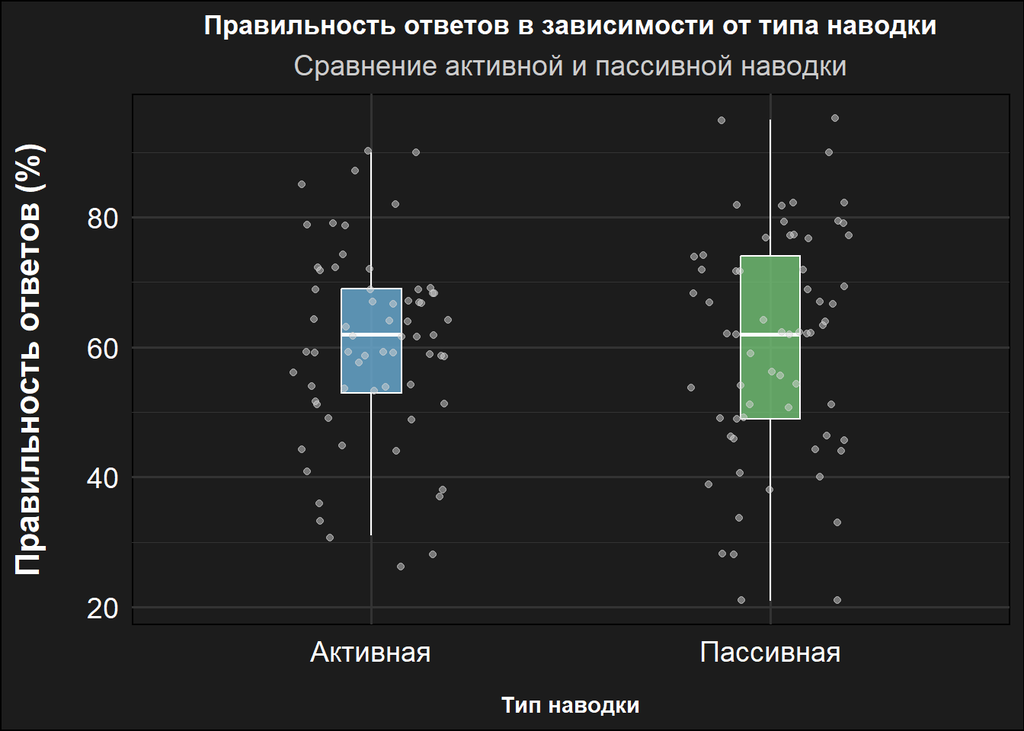

```r
accuracy_data %>%
  group_by(ID, Condition) %>%
  summarise(right_per = ((sum(Accuracy) / length(Accuracy)) * 100) %>% round(0)) %>%
  ungroup() %>%
  ggplot(aes(x = as.factor(Condition), y = right_per, fill = as.factor(Condition))) +
  geom_boxplot(width = 0.15, alpha = 0.8, outlier.shape = NA, color = "white", size = 0.5) +  # Белые линии
  geom_jitter(width = 0.2, alpha = 0.5, color = "lightgray") +  # Светло-серые точки
  scale_fill_manual(values = c("1" = "#6baed6", "2" = "#74c476")) +  # Более светлые цвета для контраста
  scale_x_discrete(labels = c('1' = 'Активная', '2' = 'Пассивная')) +
  labs(
    x = "\nТип наводки",
    y = 'Правильность ответов (%)\n',
    title = "Правильность ответов в зависимости от типа наводки",
    subtitle = "Сравнение активной и пассивной наводки"
  ) +
  theme_minimal(base_size = 14) +  # Минималистичная тема
  theme(
    plot.background = element_rect(fill = "#1c1c1c"),  # Чёрный фон
    panel.background = element_rect(fill = "#1c1c1c"),  # Чёрный фон для панели
    panel.grid.major = element_line(color = "#333333"),  # Тёмно-серые линии сетки
    panel.grid.minor = element_line(color = "#333333"),  # Тёмно-серые линии сетки
    axis.title.x = element_text(face = "bold", color = "white", size = 11),  # Белый текст
    axis.text.x = element_text(vjust = 0.5, size = 14, color = "white"),  # Белый текст
    axis.title.y = element_text(face = "bold", color = "white", size = 16),  # Белый текст
    axis.text.y = element_text(vjust = 0.5, size = 14, color = "white"),  # Белый текст
    plot.title = element_text(face = "bold", size = 13, hjust = 0.5, color = "white"),  # Белый заголовок
    plot.subtitle = element_text(size = 14, hjust = 0.5, color = "#cccccc"),  # Светло-серый подзаголовок
    legend.position = "none"  # Убираем легенду
  )
```

### Анализ правильности ответов (смешанные модели)

Смешанная регрессионная модель включала в себя правильность ответа как бинарную зависимую переменную, тип анаграммы как предиктор (условие с наводкой было задано как базовый уровень предиктора), а также ID добровольца, ID стимула и длину стимула (5/6 букв в анаграмме) как случайные факторы.

Модель, с предикторами

```r
accuracy_mdl_1 <- glmer(
                        Accuracy ~ Condition + (1|ID) + (1|Letters_y) + (1|Answer.Corr),
                        accuracy_data,
                        family = binomial)
#accuracy_mdl_1 %>% summary()
accuracy_mdl_1 %>% summary()
```

```
## Generalized linear mixed model fit by maximum likelihood (Laplace
##   Approximation) [glmerMod]
##  Family: binomial  ( logit )
## Formula: Accuracy ~ Condition + (1 | ID) + (1 | Letters_y) + (1 | Answer.Corr)
##    Data: accuracy_data
##
##      AIC      BIC   logLik deviance df.resid
##   5827.1   5859.7  -2908.5   5817.1     5022
##
## Scaled residuals:
##     Min      1Q  Median      3Q     Max
## -4.3916 -0.7669  0.3818  0.6697  3.5612
##
## Random effects:
##  Groups      Name        Variance Std.Dev.
##  Answer.Corr (Intercept) 0.94899  0.9742
##  ID          (Intercept) 0.56893  0.7543
##  Letters_y   (Intercept) 0.03341  0.1828
## Number of obs: 5027, groups:  Answer.Corr, 78; ID, 65; Letters_y, 2
##
## Fixed effects:
##             Estimate Std. Error z value Pr(>|z|)
## (Intercept)  0.54358    0.19991   2.719  0.00655 **
## Condition2   0.02174    0.06561   0.331  0.74040
## ---
## Signif. codes:  0 '***' 0.001 '**' 0.01 '*' 0.05 '.' 0.1 ' ' 1
##
## Correlation of Fixed Effects:
##            (Intr)
## Condition2 -0.163
```

```r
accuracy_mdl_1 %>% summ()
```

```
## MODEL INFO:
## Observations: 5027
## Dependent Variable: Accuracy
## Type: Mixed effects generalized linear regression
## Error Distribution: binomial
## Link function: logit
##
## MODEL FIT:
## AIC = 5827.07, BIC = 5859.68
## Pseudo-R² (fixed effects) = 0.00
## Pseudo-R² (total) = 0.32
##
## FIXED EFFECTS:
## -----------------------------------------------
##                     Est.   S.E.   z val.      p
## ----------------- ------ ------ -------- ------
## (Intercept)         0.54   0.20     2.72   0.01
## Condition2          0.02   0.07     0.33   0.74
## -----------------------------------------------
##
## RANDOM EFFECTS:
## ---------------------------------------
##     Group       Parameter    Std. Dev.
## ------------- ------------- -----------
##  Answer.Corr   (Intercept)     0.97
##      ID        (Intercept)     0.75
##   Letters_y    (Intercept)     0.18
## ---------------------------------------
##
## Grouping variables:
## -------------------------------
##     Group      # groups   ICC
## ------------- ---------- ------
##  Answer.Corr      78      0.20
##      ID           65      0.12
##   Letters_y       2       0.01
## -------------------------------
```

Оценка Cooks’ distance (Это мера того, насколько изменяются предсказания модели, если исключить одно наблюдение.)

```r
cooksd <- cooks.distance(accuracy_mdl_1)
```

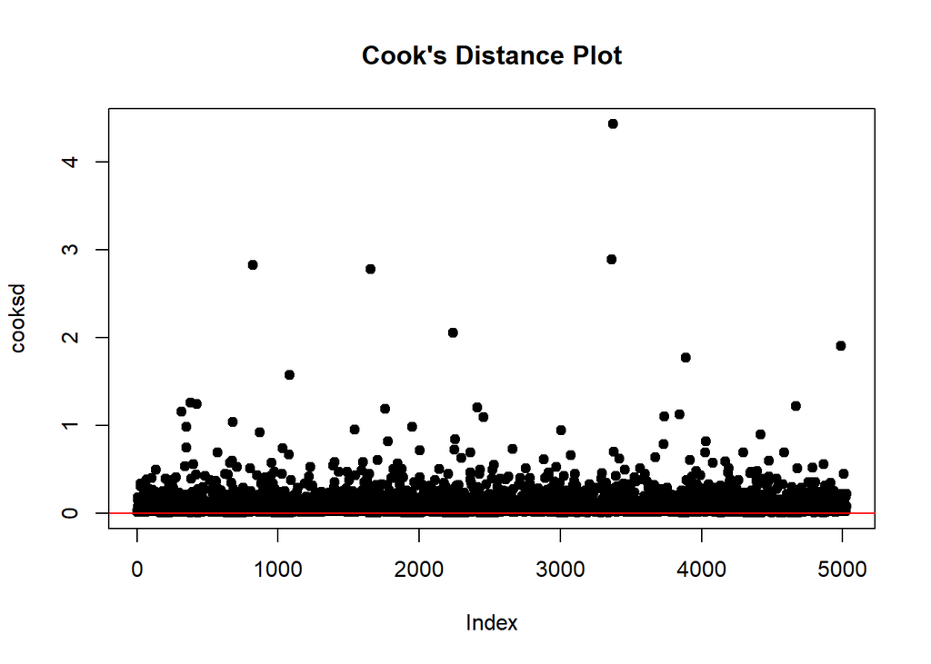

```r
plot(cooksd, pch = 19, main = "Cook's Distance Plot")
abline(h = 4/length(cooksd), col = "red")  # Пороговая линия
```

## Анализ времени правильных ответов

### Отсев

Из анализа были исключены пробы, где на первом этапе отсутствовал правильный ответ; пробы длительностью менее 200 мс (случайные нажатия); пробы, время ответа в которых превышает 3 стандартных отклонения (выбросы).

```r
full_data$dropout_1h <- 0
rt_data <- full_data %>% filter(group == "эксп")

# отсев по критериям
min_rt <- mean(rt_data$Target.RT) - 3 * sd(rt_data$Target.RT)
max_rt <- mean(rt_data$Target.RT) + 3 * sd(rt_data$Target.RT)
full_data[(
  (full_data$group == "эксп") & (
  (full_data$Target.RT < 200) |
  (full_data$Target.RT <  min_rt) |
  (full_data$Target.RT > max_rt) |
  (full_data$Accuracy == 0))
), "dropout_1h"] <- 1

full_data[!is.na(full_data$dropout_1) & full_data$dropout_1 == 1, ]$dropout_1h <- 1

if(nrow(full_data[!is.na(full_data$exclude) & full_data$exclude == 1, ]) > 0)
  full_data[!is.na(full_data$exclude) & full_data$exclude == 1, ]$dropout_1h <- 1

full_data %>%
  filter(group == "эксп" & dropout_1h == 0) -> rt_data
```

### Кол-во проб для анализа

```r
rt_data %>% nrow()
```

```
## [1] 2929
```

### Описательные статистики для условий с наводкой без наводки

```r
rt_data %>%
  group_by(Condition) %>%
  summarise(M = mean(Target.RT), SD = sd(Target.RT))
```

```
## # A tibble: 2 × 3
##   Condition     M    SD
##   <chr>     <dbl> <dbl>
## 1 1         7207. 4876.
## 2 2         6894. 4893.
```

### Тест на нормальность

```r
rt_data$Target.RT %>% shapiro.test()
```

```
##
##  Shapiro-Wilk normality test
##
## data:  .
## W = 0.91756, p-value < 2.2e-16
```

```r
rt_data$Target.RT %>% log() %>% shapiro.test()
```

```
##
##  Shapiro-Wilk normality test
##
## data:  .
## W = 0.97269, p-value < 2.2e-16
```

График распределения

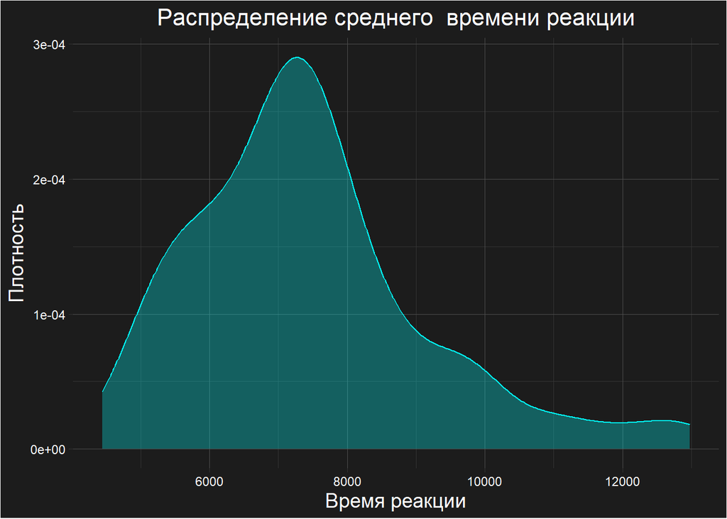

```r
rt_data %>%
  group_by(Answer.Corr) %>%
  summarise(rt = mean(Target.RT)) %>%
  ungroup() %>%
  ggplot(aes(rt)) +
  geom_density(color = "cyan", fill = "cyan", alpha = 0.3) +  # Изменение цвета и прозрачности
  labs(title = "Распределение среднего  времени реакции",
       x = "Время реакции",
       y = "Плотность") +
  theme_dark() +  # Черный фон
  theme(
    plot.background = element_rect(fill = "#1c1c1c"),  # Чёрный фон
    panel.background = element_rect(fill = "#1c1c1c"),  # Чёрный фон для панели
    plot.title = element_text(color = "white", size = 16, hjust = 0.5),  # Настройка заголовка
    axis.title = element_text(color = "white", size = 14),  # Настройка подписей осей
    axis.text = element_text(color = "white"),  # Настройка текста осей
    panel.grid.major = element_line(color = "gray30"),  # Настройка сетки
    panel.grid.minor = element_line(color = "gray20")
  )
```

График нормальности по логарифмированному времени ответа

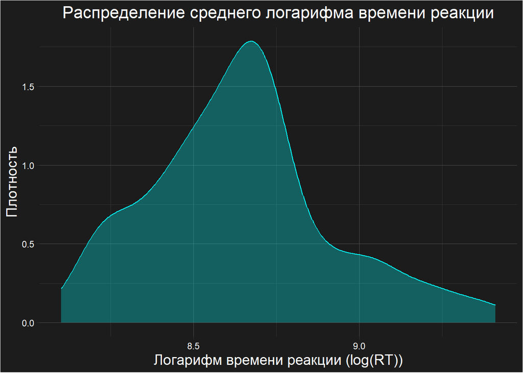

```r
rt_data %>%
  group_by(Answer.Corr) %>%
  summarise(rt = mean(log(Target.RT))) %>%
  ungroup() %>%
  ggplot(aes(rt)) +
  geom_density(color = "cyan", fill = "cyan", alpha = 0.3) +  # Изменение цвета и прозрачности
  labs(title = "Распределение среднего логарифма времени реакции",
       x = "Логарифм времени реакции (log(RT))",
       y = "Плотность") +
  theme_dark() +  # Черный фон
  theme(
    plot.background = element_rect(fill = "#1c1c1c"),  # Чёрный фон
    panel.background = element_rect(fill = "#1c1c1c"),  # Чёрный фон для панели
    plot.title = element_text(color = "white", size = 16, hjust = 0.5),  # Настройка заголовка
    axis.title = element_text(color = "white", size = 14),  # Настройка подписей осей
    axis.text = element_text(color = "white"),  # Настройка текста осей
    panel.grid.major = element_line(color = "gray30"),  # Настройка сетки
    panel.grid.minor = element_line(color = "gray20")
  )
```

### Анализ среднего времени ответа

Для анализа времени ответа на первом этапе в экспериментальной группе были использованы t-критерий Вилкиксона зависимых выборок с усреднением по анаграмме и типу анаграммы

```r
rt_data %>%
  group_by(Answer.Corr, Condition) %>%
  summarise(rt = mean(Target.RT)) %>%
  ungroup() %>%
  rstatix::wilcox_test(rt ~ Condition, paired = TRUE, alternative = "two.sided")
```

```
## # A tibble: 1 × 7
##   .y.   group1 group2    n1    n2 statistic     p
## * <chr> <chr>  <chr>  <int> <int>     <dbl> <dbl>
## 1 rt    1      2         78    78      1738 0.326
```

### Анализ времени ответа (смешанные модели)

Далее была построена смешанная регрессионная модель с зависимой переменной времени ответа и независимой переменной тип анаграммы (условие без наводки было задано как базовый уровень для модели). В качестве случайных факторов выступали ID добровольца и ID стимула.

```r
rt_data$Letters_y <- rt_data$Letters_y %>% as.numeric() %>% as.factor()
rt_data$ID <- rt_data$ID %>% as.factor()
rt_data$List_y <- rt_data$List_y %>% as.factor()
rt_data$Answer.Corr <- rt_data$Answer.Corr %>% as.factor()
```

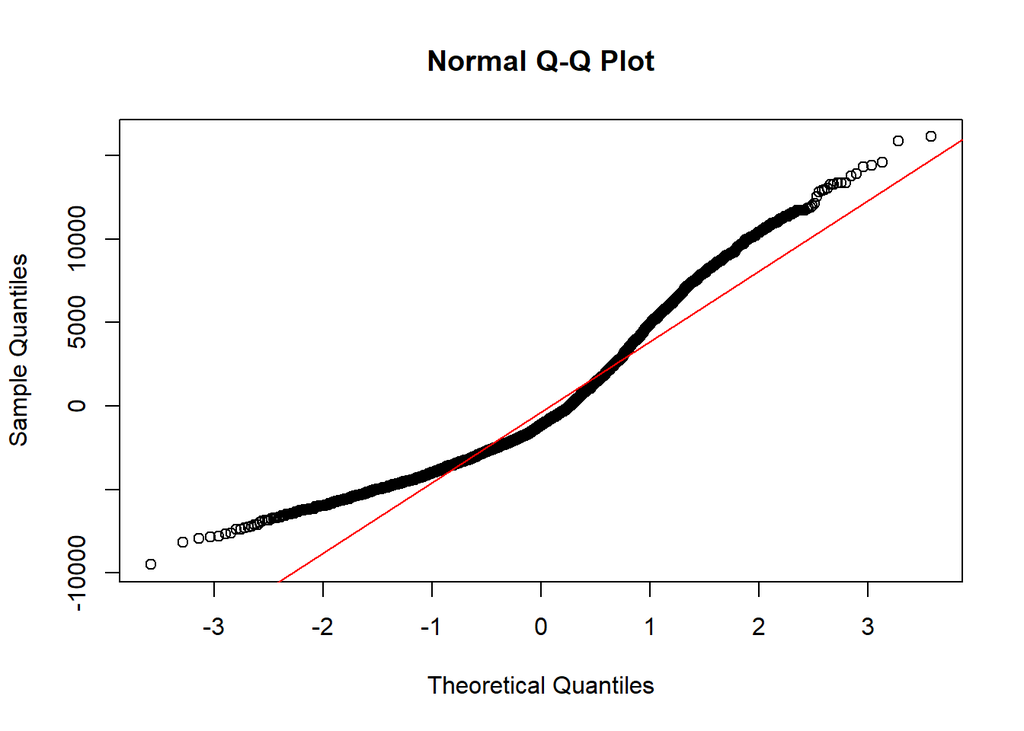

```r
rt_mdl_1 <- lmer(
                Target.RT ~ Condition + (1|ID) + (1|Answer.Corr),
                rt_data,
                REML = FALSE
              )
residuals <- resid(rt_mdl_1)
qqnorm(residuals)
qqline(residuals, col = "red")
```

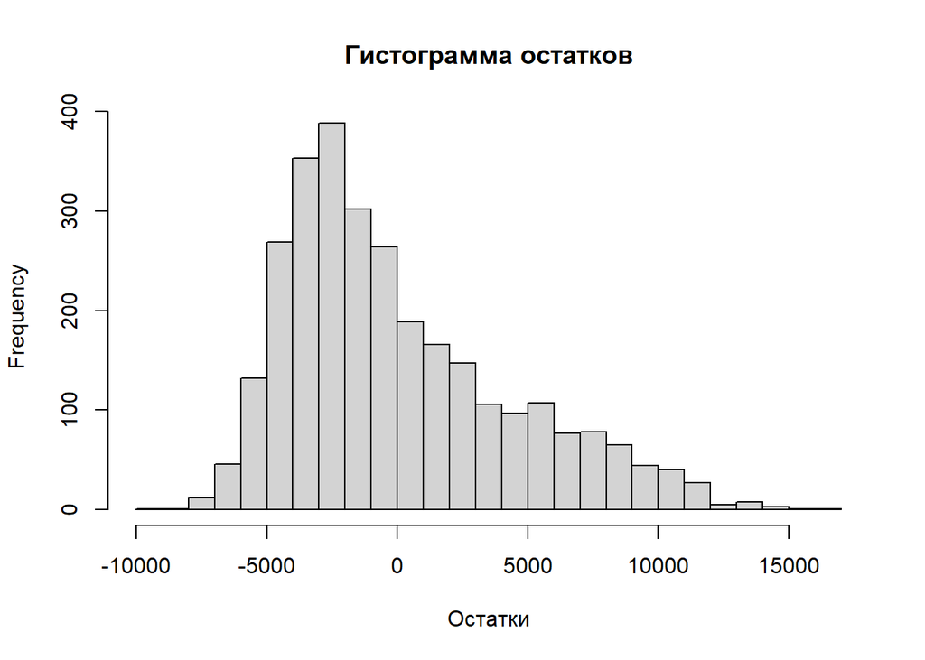

```r
hist(residuals, breaks = 30, main = "Гистограмма остатков", xlab = "Остатки")
```

```r
ks.test(residuals, "pnorm", mean = mean(residuals), sd = sd(residuals))
```

```
##
##  Asymptotic one-sample Kolmogorov-Smirnov test
##
## data:  residuals
## D = 0.1116, p-value < 2.2e-16
## alternative hypothesis: two-sided
```

```r
#rt_mdl_1 %>% summary()
```

Остатки не распределены нормально, в связи с этим нужно использовать другое распределение

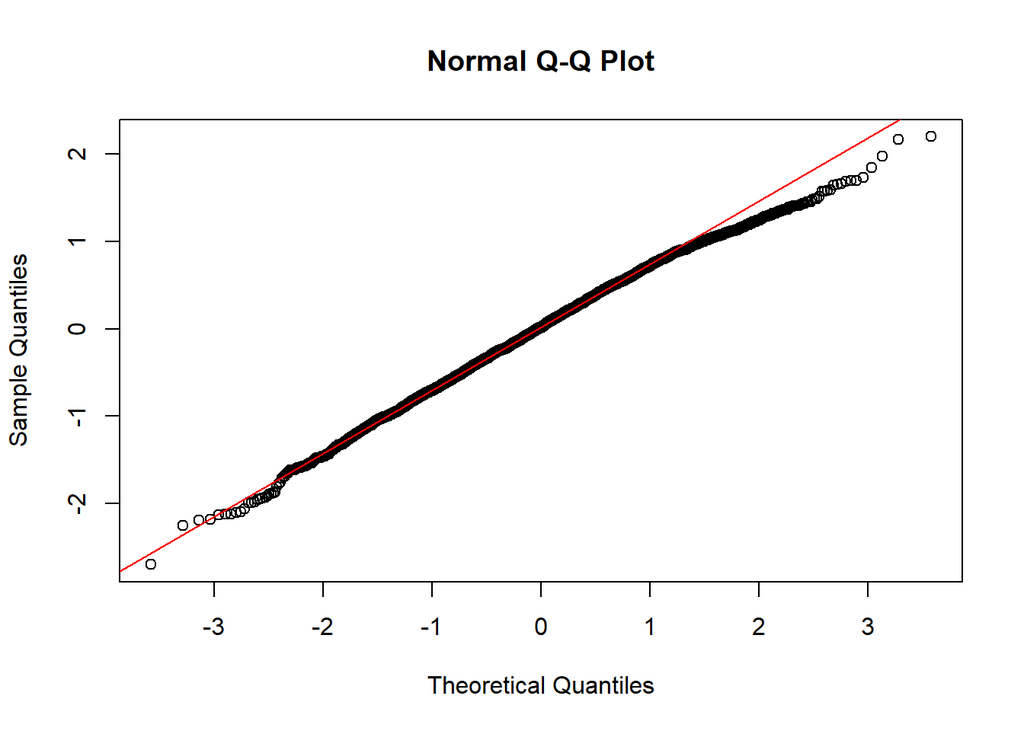

```r
rt_mdl_2 <- lmer(
                log(Target.RT) ~ Condition + (1|ID) + (1|Answer.Corr),
                rt_data,
                REML = FALSE
              )
residuals <- resid(rt_mdl_2)
qqnorm(residuals)
qqline(residuals, col = "red")
```

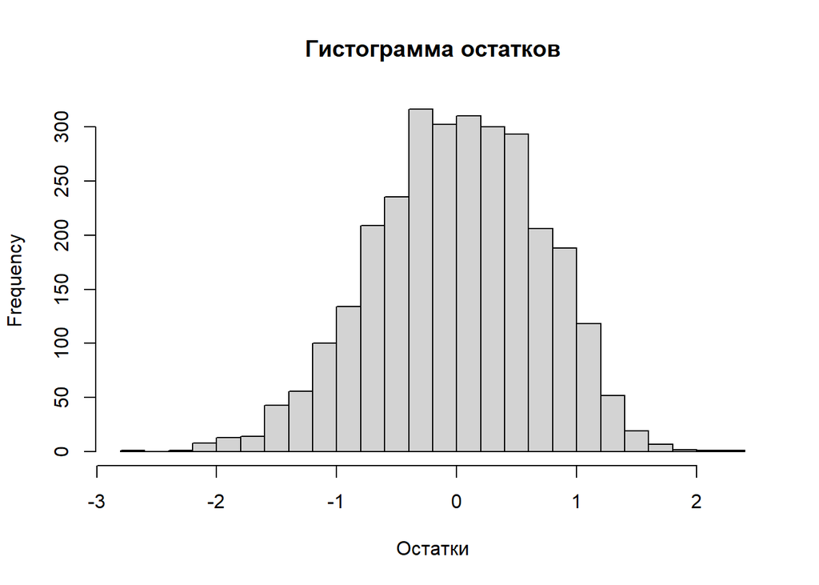

```r
hist(residuals, breaks = 30, main = "Гистограмма остатков", xlab = "Остатки")
```

```r
ks.test(residuals, "pnorm", mean = mean(residuals), sd = sd(residuals))
```

```
##
##  Asymptotic one-sample Kolmogorov-Smirnov test
##
## data:  residuals
## D = 0.023047, p-value = 0.08906
## alternative hypothesis: two-sided
```

```r
rt_mdl_2 %>% summary()
```

```
## Linear mixed model fit by maximum likelihood . t-tests use Satterthwaite's
##   method [lmerModLmerTest]
## Formula: log(Target.RT) ~ Condition + (1 | ID) + (1 | Answer.Corr)
##    Data: rt_data
##
##      AIC      BIC   logLik deviance df.resid
##   6581.6   6611.5  -3285.8   6571.6     2924
##
## Scaled residuals:
##     Min      1Q  Median      3Q     Max
## -3.8178 -0.6621  0.0203  0.7157  3.1079
##
## Random effects:
##  Groups      Name        Variance Std.Dev.
##  Answer.Corr (Intercept) 0.06648  0.2578
##  ID          (Intercept) 0.09745  0.3122
##  Residual                0.50173  0.7083
## Number of obs: 2929, groups:  Answer.Corr, 78; ID, 65
##
## Fixed effects:
##               Estimate Std. Error         df t value Pr(>|t|)
## (Intercept)    8.72263    0.05235  120.87864 166.633   <2e-16 ***
## Condition2    -0.05752    0.02643 2797.50183  -2.177   0.0296 *
## ---
## Signif. codes:  0 '***' 0.001 '**' 0.01 '*' 0.05 '.' 0.1 ' ' 1
##
## Correlation of Fixed Effects:
##            (Intr)
## Condition2 -0.253
```

```r
rt_mdl_2 %>% summ()
```

```
## MODEL INFO:
## Observations: 2929
## Dependent Variable: log(Target.RT)
## Type: Mixed effects linear regression
##
## MODEL FIT:
## AIC = 6581.63, BIC = 6611.54
## Pseudo-R² (fixed effects) = 0.00
## Pseudo-R² (total) = 0.25
##
## FIXED EFFECTS:
## ----------------------------------------------------------
##                      Est.   S.E.   t val.      d.f.      p
## ----------------- ------- ------ -------- --------- ------
## (Intercept)          8.72   0.05   166.63    120.88   0.00
## Condition2          -0.06   0.03    -2.18   2797.50   0.03
## ----------------------------------------------------------
##
## p values calculated using Satterthwaite d.f.
##
## RANDOM EFFECTS:
## ---------------------------------------
##     Group       Parameter    Std. Dev.
## ------------- ------------- -----------
##  Answer.Corr   (Intercept)     0.26
##      ID        (Intercept)     0.31
##   Residual                     0.71
## ---------------------------------------
##
## Grouping variables:
## -------------------------------
##     Group      # groups   ICC
## ------------- ---------- ------
##  Answer.Corr      78      0.10
##      ID           65      0.15
## -------------------------------
```

## Анализ вероятности возникновения ага-переживания при правильном решении в зависимости от типа анаграммы

С целью проверки гипотезы о том, что решение анаграмм с наличием слова-наводки будет происходить путем переструктурирования и чаще сопровождаться ага-переживанием, был произведён анализ отчетов об ага-переживании при нахождении правильного ответа.

### Отсев

Были исключены пробы с неправильным ответом; ошибочные отчёты о том, что анаграмма не решена, хотя на самом деле ответ был дан; данные добровольцев, сообщивших о наличии ага-переживания менее, чем в 10% или более чем в 90% случаев.

```r
full_data$dropout_2h <- 0
full_data[(
  (full_data$group == "эксп") & (
  (full_data$Accuracy == 0) |
  (full_data$Q1Aha.RESP == 3))
), "dropout_2h"] <- 1

full_data <- full_data %>%
          left_join(full_data %>%
                      group_by(ID) %>%
                      summarise(
                        aha_per = ((sum(Q1Aha.RESP[Accuracy == 1 & Q1Aha.RESP == 1])) / sum(Accuracy) * 100)  %>% round(0),
                      ) %>%
                      ungroup() %>%
                      select(ID, aha_per)
                    , by = 'ID')
```

Отсев людей, где ага было больше 90 и меньше 10 процентов

```r
full_data[(
  (full_data$group == "эксп") & (
  (full_data$aha_per < 10) |
  (full_data$aha_per > 90))
), "dropout_2h"] <- 1

full_data[!is.na(full_data$dropout_1) & full_data$dropout_1 == 1, ]$dropout_2h <- 1
if(nrow(full_data[!is.na(full_data$exclude) & full_data$exclude == 1, ]) > 0)
  full_data[!is.na(full_data$exclude) & full_data$exclude == 1, ]$dropout_2h <- 1
```

```r
full_data %>%
  filter(group == "эксп" & dropout_2h == 0) -> aha_data
```

### Кол-во проб для анализа

```r
aha_data %>% nrow()
```

```
## [1] 2656
```

### Статистика по ага

```r
aha_data$Q1Aha.RESP %>% table()
```

```
## .
##    1    2
## 1335 1321
```

### Анализ доли ага

подсчёт доли ага

```r
aha_data %>%
  group_by(Answer.Corr, Condition) %>%
  summarise(aha = sum(Q1Aha.RESP[Q1Aha.RESP ==  1]),
            all = sum(Accuracy)) %>%
  ungroup() -> aha_data
aha_data$aha_per <-aha_data$aha / aha_data$all
```

Опистальные статистики

```r
aha_data %>%
  group_by(Condition) %>%
  summarise(M = mean(aha_per), SD = sd(aha_per))
```

```
## # A tibble: 2 × 3
##   Condition     M    SD
##   <chr>     <dbl> <dbl>
## 1 1         0.509 0.147
## 2 2         0.499 0.116
```

```r
# проверка на нормальность распределения
shapiro.test(aha_data[aha_data$Condition == 1, ]$aha_per - aha_data[aha_data$Condition == 2, ]$aha_per)
```

```
##
##  Shapiro-Wilk normality test
##
## data:  aha_data[aha_data$Condition == 1, ]$aha_per - aha_data[aha_data$Condition == 2, ]$aha_per
## W = 0.98582, p-value = 0.5414
```

```r
# wilx test
aha_data %>%
  rstatix::t_test(aha_per ~ Condition, paired = TRUE, alternative = "two.sided")
```

```
## # A tibble: 1 × 8
##   .y.     group1 group2    n1    n2 statistic    df     p
## * <chr>   <chr>  <chr>  <int> <int>     <dbl> <dbl> <dbl>
## 1 aha_per 1      2         78    78     0.495    77 0.622
```

### Анализ частотности

```r
full_data %>%
  filter(group == "эксп" & dropout_2h == 0) -> aha_data


chisq.test(table(aha_data$Q1Aha.RESP, aha_data$Condition))
```

```
##
##  Pearson's Chi-squared test with Yates' continuity correction
##
## data:  table(aha_data$Q1Aha.RESP, aha_data$Condition)
## X-squared = 0.074579, df = 1, p-value = 0.7848
```

### Анализ агашности (смешанные модели)

```r
full_data %>%
  filter(group == "эксп" & dropout_2h == 0) -> aha_data

aha_data$Q1Aha.RESP <- aha_data$Q1Aha.RESP %>% as.factor()

aha_mdl_1 <- glmer(
                  Q1Aha.RESP ~ Condition + (1|ID) + (1|Answer.Corr),
                  aha_data,
                  family = binomial)
#accuracy_mdl_1 %>% summary()
aha_mdl_1 %>% summary()
```

```
## Generalized linear mixed model fit by maximum likelihood (Laplace
##   Approximation) [glmerMod]
##  Family: binomial  ( logit )
## Formula: Q1Aha.RESP ~ Condition + (1 | ID) + (1 | Answer.Corr)
##    Data: aha_data
##
##      AIC      BIC   logLik deviance df.resid
##   3352.2   3375.8  -1672.1   3344.2     2652
##
## Scaled residuals:
##     Min      1Q  Median      3Q     Max
## -2.1840 -0.8047 -0.3977  0.7916  2.4109
##
## Random effects:
##  Groups      Name        Variance Std.Dev.
##  Answer.Corr (Intercept) 0.03264  0.1807
##  ID          (Intercept) 0.90638  0.9520
## Number of obs: 2656, groups:  Answer.Corr, 78; ID, 56
##
## Fixed effects:
##              Estimate Std. Error z value Pr(>|z|)
## (Intercept) -0.061949   0.143091  -0.433    0.665
## Condition2   0.004905   0.085276   0.058    0.954
##
## Correlation of Fixed Effects:
##            (Intr)
## Condition2 -0.298
```

Оценка Cooks’ distance (Это мера того, насколько изменяются предсказания модели, если исключить одно наблюдение.)

```r
cooksd <- cooks.distance(aha_mdl_1)
```

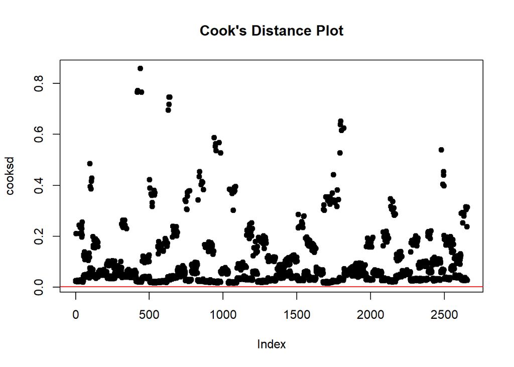

```r
plot(cooksd, pch = 19, main = "Cook's Distance Plot")
abline(h = 4/length(cooksd), col = "red")  # Пороговая линия
```

# Сравнение результатов экспериментальной и контрольной групп на втором (дистанционном) этапе

Проводился сравнительный анализ доли правильных ответов и времени правильных ответов на втором этапе с целью проверки гипотезы о том, что повторное решение анаграмм на втором этапе (экспериментальная группа) будет более успешным, чем первичное (контрольная группа) в силу мнемического эффекта, а именно: доля решённых анаграмм будет значимо больше, при этом решение анаграмм будет происходить значимо быстрее в экспериментальной группе, чем в контрольной.

### Отсев

```r
full_data$dropout_inter_group <- 0
full_data[!is.na(full_data$dropout_1) & full_data$dropout_1 == 1, ]$dropout_inter_group <- 1

full_data[!is.na(full_data$dropout_2) & full_data$dropout_2 == 1, ]$dropout_inter_group <- 1

if(nrow(full_data[!is.na(full_data$exclude) & full_data$exclude == 1, ]) > 0)
  full_data[!is.na(full_data$exclude) & full_data$exclude == 1, ]$dropout_inter_group <- 1

full_data$dropout_inter_group  %>%  table()
```

```
## .
##    0    1
## 9301  371
```

```r
full_data %>%
  filter(dropout_inter_group == 0) -> intr_group_data
```

### Кол-во проб для анализа

```r
intr_group_data %>% nrow()
```

```
## [1] 9301
```

Количество проб в разных группах

```r
intr_group_data$group %>% table()
```

```
## .
## контроль     эксп
##     4290     5011
```

### Сравнение процента правильных ответов в ЭГ и КГ

```r
intr_group_data %>%
  group_by(Answer.Corr, group) %>%
  summarise(right_per = ((sum(Accuracy2) / length(Accuracy2)) * 100) %>% round(0)) %>%
  ungroup() %>%
  rstatix::shapiro_test(right_per)
```

```
## # A tibble: 1 × 3
##   variable  statistic       p
##   <chr>         <dbl>   <dbl>
## 1 right_per     0.972 0.00280
```

```r
# wilcox test
intr_group_data %>%
  group_by(Answer.Corr, group) %>%
  summarise(right_per = ((sum(Accuracy2) / length(Accuracy2)) * 100) %>% round(0)) %>%
  ungroup() %>%
  rstatix::wilcox_test(right_per ~ group, paired = TRUE, alternative = "two.sided")
```

```
## # A tibble: 1 × 7
##   .y.       group1   group2    n1    n2 statistic             p
## * <chr>     <chr>    <chr>  <int> <int>     <dbl>         <dbl>
## 1 right_per контроль эксп      78    78       291 0.00000000079
```

```r
# effect size
intr_group_data %>%
  group_by(Answer.Corr, group) %>%
  summarise(right_per = ((sum(Accuracy2) / length(Accuracy2)) * 100) %>% round(0)) %>%
  ungroup() %>%
  rstatix::wilcox_effsize(right_per ~ group, paired = TRUE, alternative = "two.sided")
```

```
## # A tibble: 1 × 7
##   .y.       group1   group2 effsize    n1    n2 magnitude
## * <chr>     <chr>    <chr>    <dbl> <int> <int> <ord>
## 1 right_per контроль эксп     0.698    78    78 large
```

#### Описательные статистики

```r
intr_group_data %>%
  group_by(Answer.Corr, group) %>%
  summarise(right_per = ((sum(Accuracy2) / length(Accuracy2)) * 100) %>% round(0)) %>%
  ungroup() %>%
  group_by(group) %>%
  summarise(M = median(right_per), SD = IQR(right_per))
```

```
## # A tibble: 2 × 3
##   group        M    SD
##   <chr>    <dbl> <dbl>
## 1 контроль    58  30.5
## 2 эксп        71  28.2
```

#### Анализ частот

```r
intr_group_data %>%
  select(Accuracy2, group) %>%
  table() %>%
  chisq.test()
```

```
##
##  Pearson's Chi-squared test with Yates' continuity correction
##
## data:  .
## X-squared = 59.824, df = 1, p-value = 1.037e-14
```

#### График

```
## argument.
```

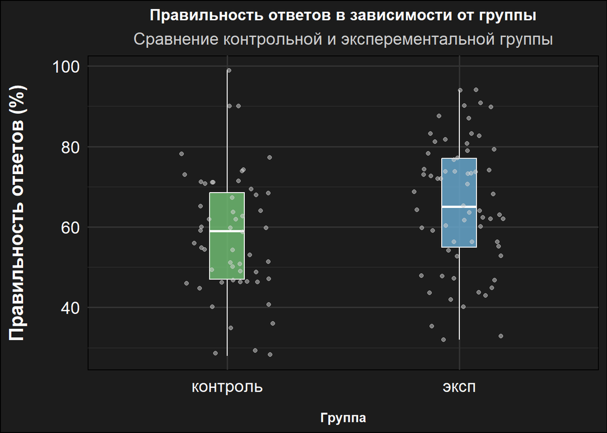

```r
intr_group_data %>%
  group_by(ID, group) %>%
  summarise(right_per = ((sum(Accuracy2) / length(Accuracy2)) * 100) %>% round(0)) %>%
  ungroup() %>%
  ggplot(aes(x = as.factor(group), y = right_per, fill = as.factor(group))) +
  geom_boxplot(width = 0.15, alpha = 0.8, outlier.shape = NA, color = "white", size = 0.5) +  # Белые линии
  geom_jitter(width = 0.2, alpha = 0.5, color = "lightgray") +  # Светло-серые точки
  scale_fill_manual(values = c("эксп" = "#6baed6", "контроль" = "#74c476")) +  # Более светлые цвета для контраста
  #scale_x_discrete(labels = c('1' = 'Активная', '2' = 'Пассивная')) +
  labs(
    x = "\nГруппа",
    y = 'Правильность ответов (%)\n',
    title = "Правильность ответов в зависимости от группы",
    subtitle = "Сравнение контрольной и эксперементальной группы"
  ) +
  theme_minimal(base_size = 14) +  # Минималистичная тема
  theme(
    plot.background = element_rect(fill = "#1c1c1c"),  # Чёрный фон
    panel.background = element_rect(fill = "#1c1c1c"),  # Чёрный фон для панели
    panel.grid.major = element_line(color = "#333333"),  # Тёмно-серые линии сетки
    panel.grid.minor = element_line(color = "#333333"),  # Тёмно-серые линии сетки
    axis.title.x = element_text(face = "bold", color = "white", size = 11),  # Белый текст
    axis.text.x = element_text(vjust = 0.5, size = 14, color = "white"),  # Белый текст
    axis.title.y = element_text(face = "bold", color = "white", size = 16),  # Белый текст
    axis.text.y = element_text(vjust = 0.5, size = 14, color = "white"),  # Белый текст
    plot.title = element_text(face = "bold", size = 13, hjust = 0.5, color = "white"),  # Белый заголовок
    plot.subtitle = element_text(size = 14, hjust = 0.5, color = "#cccccc"),  # Светло-серый подзаголовок
    legend.position = "none"  # Убираем легенду
  )
```

### Сравнение времени правильных ответов в ЭГ и КГ

#### Отсев

```r
full_data %>%
  filter(dropout_inter_group == 0) -> intr_group_data

intr_group_data %>%
  filter( exclude == 0 &
          Accuracy2 == 1 &
          Target.RT2 > 200) -> intr_group_data

min_rt <- mean(intr_group_data$Target.RT2) - 3 * sd(intr_group_data$Target.RT2)
max_rt <- mean(intr_group_data$Target.RT2) + 3 * sd(intr_group_data$Target.RT2)
intr_group_data <- intr_group_data %>% filter(Target.RT2 > min_rt & Target.RT2 < max_rt)
```

```r
intr_group_data %>% nrow()
```

```
## [1] 5469
```

#### Описательные статистики

```r
intr_group_data %>%
  group_by(group) %>%
  summarise(M = median(Target.RT2), iqr = IQR(Target.RT2))
```

```
## # A tibble: 2 × 3
##   group        M   iqr
##   <chr>    <dbl> <dbl>
## 1 контроль 8622. 7646.
## 2 эксп     6656  6634
```

#### Сравнение на нормальность

```r
shapiro.test(intr_group_data$Target.RT2[intr_group_data$group == 'эксп'])
```

```
##
##  Shapiro-Wilk normality test
##
## data:  intr_group_data$Target.RT2[intr_group_data$group == "эксп"]
## W = 0.9123, p-value < 2.2e-16
```

```r
shapiro.test(intr_group_data$Target.RT2[intr_group_data$group != 'эксп'])
```

```
##
##  Shapiro-Wilk normality test
##
## data:  intr_group_data$Target.RT2[intr_group_data$group != "эксп"]
## W = 0.93799, p-value < 2.2e-16
```

#### Вилкоксон сравнение

```r
intr_group_data %>%
  group_by(Answer.Corr, group) %>%
  summarise(rt = mean(Target.RT2)) %>%
  ungroup() %>%
  rstatix::wilcox_test(rt ~ group, paired = FALSE, alternative = "two.sided")
```

```
## # A tibble: 1 × 7
##   .y.   group1   group2    n1    n2 statistic        p
## * <chr> <chr>    <chr>  <int> <int>     <dbl>    <dbl>
## 1 rt    контроль эксп      78    78      4797 5.01e-10
```

```r
intr_group_data %>%
  group_by(Answer.Corr, group) %>%
  summarise(rt = mean(Target.RT2)) %>%
  ungroup() %>%
  rstatix::wilcox_effsize(rt ~ group, paired = FALSE, alternative = "two.sided")
```

```
## # A tibble: 1 × 7
##   .y.   group1   group2 effsize    n1    n2 magnitude
## * <chr> <chr>    <chr>    <dbl> <int> <int> <ord>
## 1 rt    контроль эксп     0.498    78    78 moderate
```

#### Смешанные модели

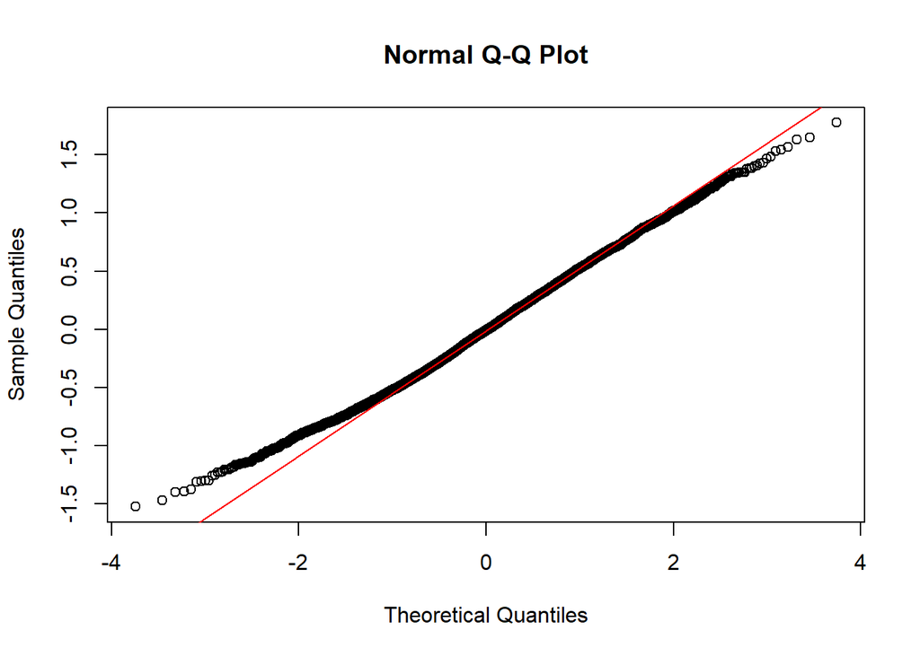

```r
intr_group_mdl_1 <- lmer(
                log(Target.RT2) ~ group + (1|ID) + (1|Answer.Corr),
                intr_group_data,
                REML = FALSE
              )

residuals <- resid(intr_group_mdl_1)
qqnorm(residuals)
qqline(residuals, col = "red")
```

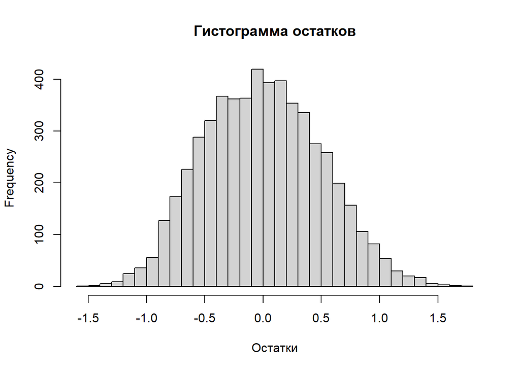

```r
hist(residuals, breaks = 30, main = "Гистограмма остатков", xlab = "Остатки")
```

```r
ks.test(residuals, "pnorm", mean = mean(residuals), sd = sd(residuals))
```

```
##
##  Asymptotic one-sample Kolmogorov-Smirnov test
##
## data:  residuals
## D = 0.02522, p-value = 0.001904
## alternative hypothesis: two-sided
```

```r
intr_group_mdl_1 %>% summary()
```

```
## Linear mixed model fit by maximum likelihood . t-tests use Satterthwaite's
##   method [lmerModLmerTest]
## Formula: log(Target.RT2) ~ group + (1 | ID) + (1 | Answer.Corr)
##    Data: intr_group_data
##
##      AIC      BIC   logLik deviance df.resid
##   8664.5   8697.5  -4327.2   8654.5     5464
##
## Scaled residuals:
##     Min      1Q  Median      3Q     Max
## -2.9863 -0.7348 -0.0200  0.6864  3.4783
##
## Random effects:
##  Groups      Name        Variance Std.Dev.
##  ID          (Intercept) 0.07650  0.2766
##  Answer.Corr (Intercept) 0.03483  0.1866
##  Residual                0.26047  0.5104
## Number of obs: 5469, groups:  ID, 120; Answer.Corr, 78
##
## Fixed effects:
##              Estimate Std. Error        df t value Pr(>|t|)
## (Intercept)   9.11107    0.04439 172.27673 205.263  < 2e-16 ***
## groupэксп    -0.21848    0.05276 119.79961  -4.141 6.47e-05 ***
## ---
## Signif. codes:  0 '***' 0.001 '**' 0.01 '*' 0.05 '.' 0.1 ' ' 1
##
## Correlation of Fixed Effects:
```

```
##           (Intr)
## groupэксп -0.648
```

график

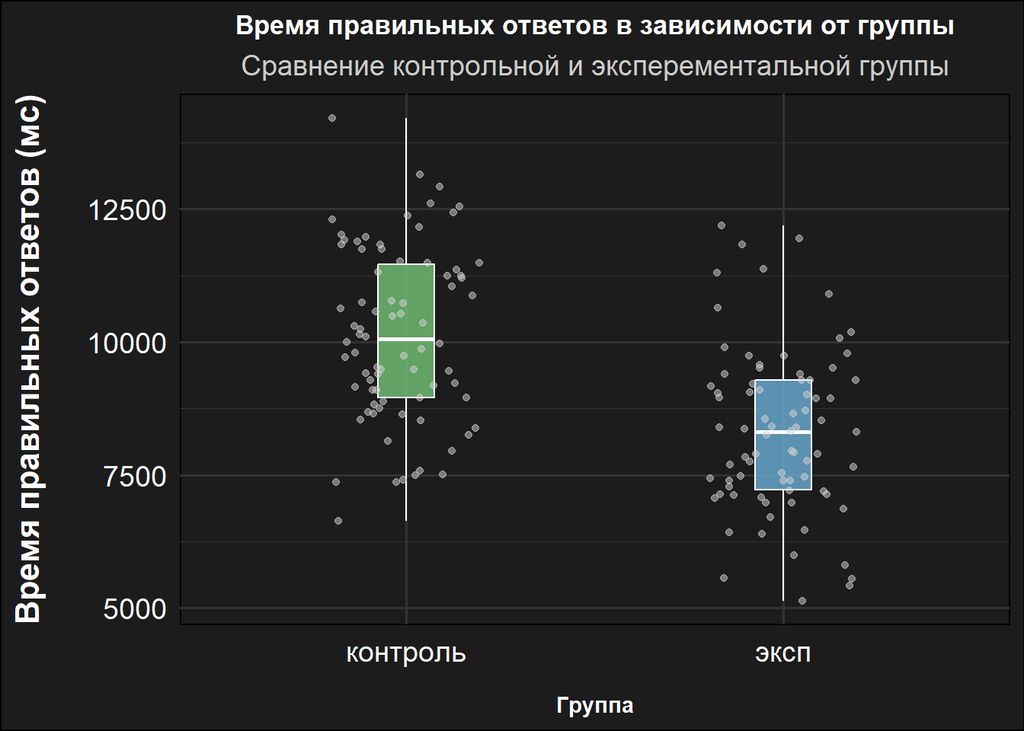

```r
intr_group_data %>%
  group_by(Answer.Corr, group) %>%
  summarise(rt = mean(Target.RT2)) %>%
  ungroup() %>%
  ggplot(aes(x = as.factor(group), y = rt, fill = as.factor(group))) +
  geom_boxplot(width = 0.15, alpha = 0.8, outlier.shape = NA, color = "white", size = 0.5) +  # Белые линии
  geom_jitter(width = 0.2, alpha = 0.5, color = "lightgray") +  # Светло-серые точки
  scale_fill_manual(values = c("эксп" = "#6baed6", "контроль" = "#74c476")) +  # Более светлые цвета для контраста
  #scale_x_discrete(labels = c('1' = 'Активная', '2' = 'Пассивная')) +
  labs(
    x = "\nГруппа",
    y = 'Время правильных ответов (мс)\n',
    title = "Время правильных ответов в зависимости от группы",
    subtitle = "Сравнение контрольной и эксперементальной группы"
  ) +
  theme_minimal(base_size = 14) +  # Минималистичная тема
  theme(
    plot.background = element_rect(fill = "#1c1c1c"),  # Чёрный фон
    panel.background = element_rect(fill = "#1c1c1c"),  # Чёрный фон для панели
    panel.grid.major = element_line(color = "#333333"),  # Тёмно-серые линии сетки
    panel.grid.minor = element_line(color = "#333333"),  # Тёмно-серые линии сетки
    axis.title.x = element_text(face = "bold", color = "white", size = 11),  # Белый текст
    axis.text.x = element_text(vjust = 0.5, size = 14, color = "white"),  # Белый текст
    axis.title.y = element_text(face = "bold", color = "white", size = 16),  # Белый текст
    axis.text.y = element_text(vjust = 0.5, size = 14, color = "white"),  # Белый текст
    plot.title = element_text(face = "bold", size = 13, hjust = 0.5, color = "white"),  # Белый заголовок
    plot.subtitle = element_text(size = 14, hjust = 0.5, color = "#cccccc"),  # Светло-серый подзаголовок
    legend.position = "none"  # Убираем легенду
  )
```

# Проверка гипотезы о мнемическом преимуществе инсайта

С целью проверки гипотезы о мнемическом преимуществе инсайта, был произведен анализ связи отчётов об ага-переживании при первом решении анаграммы с ускорением ее повторного решения на втором этапе по сравнению с первым в экспериментальной группе. Ожидалось, что в случае, если решение на первом этапе сопровождалось ага-переживанием, разница во времени первичного и повторного решения будет больше по сравнению со случаями, когда первичное решение не сопровождалось ага-переживанием, т.е. мнемический выигрыш во времени решения на втором этапе будет больше.

### Отсев

```r
full_data$dropout_3h <- 0
full_data$aha_per <- NULL

#подсчёт минимального и максимального времени реакции для каждого человека
full_data <- full_data %>%
              left_join(full_data %>%
                          filter(group == "эксп") %>%
                          filter(Target.RT2 > 0) %>%
                          group_by(ID) %>%
                          summarise(
                            aha_per = ((sum(Q1Aha.RESP[Accuracy == 1 & Q1Aha.RESP == 1])) / sum(Accuracy) * 100)  %>% round(0),
                          ) %>%
                          ungroup() %>%
                          select(ID, aha_per)
                        , by = 'ID')
min_rt <- mean(full_data[full_data$group == "эксп", ]$Target.RT2) - 3 * sd(full_data[full_data$group == "эксп", ]$Target.RT2)
max_rt <- mean(full_data[full_data$group == "эксп", ]$Target.RT2) + 3 * sd(full_data[full_data$group == "эксп", ]$Target.RT2)
# отсев по критериям
full_data[(
  (full_data$group == "эксп") & (
  (full_data$Target.RT2 < 200) |
  (full_data$Target.RT2 < min_rt) |
  (full_data$Target.RT2 > max_rt) |
  (full_data$aha_per < 10) |
  (full_data$aha_per > 90) |
  (full_data$Q1Aha.RESP == 3) |
  (full_data$Accuracy == 0) |
  (full_data$Accuracy2 == 0)
  )
), "dropout_3h"] <- 1
```

Отсев по людям

```r
full_data[!is.na(full_data$dropout_1) & full_data$dropout_1 == 1, ]$dropout_3h <- 1
```

```r
if(nrow(full_data[!is.na(full_data$exclude) & full_data$exclude == 1, ]) > 0)
  full_data[!is.na(full_data$exclude) & full_data$exclude == 1, ]$dropout_3h <- 1
```

```r
full_data %>% filter(group == "эксп" & dropout_3h == 0) -> aha_mnem_data
aha_mnem_data %>% nrow()
```

```
## [1] 2110
```

### Кол-во с ага и без ага

```r
aha_mnem_data$Q1Aha.RESP %>% table()
```

```
## .
##    1    2
## 1042 1068
```

```r
aha_mnem_data %>%
  mutate(diff = Target.RT2 - Target.RT_corr) %>%
  mutate(log_diff = log(Target.RT2) - log(Target.RT_corr)) -> aha_mnem_data

aha_mnem_data$Q1Aha.RESP <- c('aha', 'not-aha')[aha_mnem_data$Q1Aha.RESP]
aha_mnem_data$Q1Aha.RESP <- aha_mnem_data$Q1Aha.RESP %>% as.factor()
```

### График

```r
aha_mnem_data %>%
  pivot_longer(cols = c("Target.RT_corr", "Target.RT2"), names_to="stage", values_to = "RT")  -> aha_mnem_graph

aha_mnem_graph$stage = as.factor(as.numeric(aha_mnem_graph$stage != "Target.RT_corr") + 1)
```

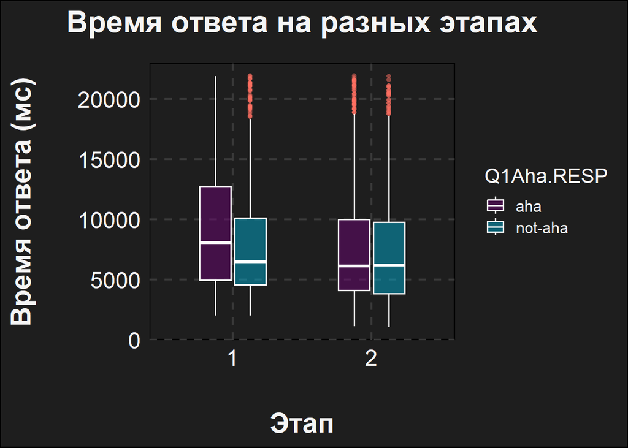

```r
aha_temp <- list('aha' = 'Ага!', 'not-aha' = 'Нет-Ага!')

labeller_temp <- function(variable,value){
  return(aha_temp[value])
}

aha_mnem_graph %>%
  ggplot(aes(stage, RT, fill = Q1Aha.RESP)) +
  geom_boxplot(
    width = 0.5,
    color = "white",          # Цвет рамки
    alpha = 0.5,              # Прозрачность заливки
    outlier.color = "#ff6f61", # Цвет выбросов
    outlier.shape = 16,       # Форма выбросов (круг)
    lwd = 0.6                 # Толщина линий
  ) +
  xlab("\nЭтап") +
  ylab("Время ответа (мс)\n") +
  theme_minimal(base_size = 16) +
  theme(
    panel.background = element_rect(fill = "#1e1e1e"), # Тёмный фон
    plot.background = element_rect(fill = "#1e1e1e"), # Тёмный фон
    panel.grid.major = element_line(color = "#3a3a3a", linetype = "dashed"), # Сетка
    panel.grid.minor = element_blank(), # Убрать мелкие линии сетки
    text = element_text(color = "#f5f5f5", family = "sans"), # Белый текст
    axis.title.x = element_text(face = "bold", size = 22, margin = margin(t = 10)),
    axis.text.x = element_text(color = "#f5f5f5", size = 18),
    axis.title.y = element_text(face = "bold", size = 22, margin = margin(r = 10)),
    axis.text.y = element_text(color = "#f5f5f5", size = 18),
    strip.text = element_text(color = "#f5f5f5", size = 18, face = "bold"), # Текст фасетов
    strip.background = element_rect(fill = "#3a3a3a", color = "#3a3a3a"), # Фон фасетов
  ) +
  scale_fill_manual(values = c("#6a0572", "#00a8cc")) + # Градиентные цвета заливки
  scale_color_manual(values = c("#6a0572", "#00a8cc")) + # Градиентные цвета линий
  ggtitle("Время ответа на разных этапах") +
  theme(
    plot.title = element_text(
      color = "#f5f5f5",
      size = 24,
      face = "bold",
      hjust = 0.5,
      margin = margin(b = 20)
    )
  )
```

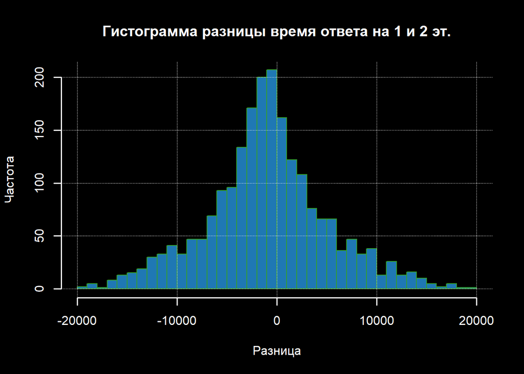

```r
par(bg = "black", fg = "white", col.main = "white", col.lab = "white", col.axis = "white")
hist(aha_mnem_data$diff,
     breaks = 30,
     main = "Гистограмма разницы время ответа на 1 и 2 эт.",
     xlab = "Разница",
     ylab = "Частота",
     col = "#1f78b4",          # Цвет столбцов
     border = "#33a02c",       # Цвет границ столбцов
     col.main = "white",       # Цвет заголовка
     col.lab = "white",        # Цвет подписей осей
     col.axis = "white",       # Цвет значений на осях
     lwd = 1.5)
grid(col = "white", lty = "dotted", lwd = 0.5)
```

### Описательные статистики

```r
aha_mnem_data %>%
  group_by(Q1Aha.RESP) %>%
  summarise(m = mean(diff), sd = sd(diff))
```

```
## # A tibble: 2 × 3
##   Q1Aha.RESP      m    sd
##   <fct>       <dbl> <dbl>
## 1 aha        -1529. 6364.
## 2 not-aha     -402. 5669.
```

### Смешанные модели

```r
aha_mnem_data$Q1Aha.RESP <- relevel(as.factor(aha_mnem_data$Q1Aha.RESP), ref = 'not-aha')

aha_mnem_mdl_1 <- lmer(log_diff ~ as.factor(Q1Aha.RESP) + (1|ID) + (1|Answer.Corr), aha_mnem_data, REML = FALSE)
aha_mnem_mdl_1 %>% summary()
```

```
## Linear mixed model fit by maximum likelihood . t-tests use Satterthwaite's
##   method [lmerModLmerTest]
## Formula: log_diff ~ as.factor(Q1Aha.RESP) + (1 | ID) + (1 | Answer.Corr)
##    Data: aha_mnem_data
##
##      AIC      BIC   logLik deviance df.resid
##   4691.8   4720.0  -2340.9   4681.8     2105
##
## Scaled residuals:
##     Min      1Q  Median      3Q     Max
## -3.2081 -0.6292 -0.0193  0.5966  3.5624
##
## Random effects:
##  Groups      Name        Variance Std.Dev.
##  Answer.Corr (Intercept) 0.02114  0.1454
##  ID          (Intercept) 0.05901  0.2429
##  Residual                0.50208  0.7086
## Number of obs: 2110, groups:  Answer.Corr, 78; ID, 55
##
## Fixed effects:
##                            Estimate Std. Error         df t value Pr(>|t|)
## (Intercept)                -0.03941    0.04399   95.65464  -0.896    0.372
## as.factor(Q1Aha.RESP)aha   -0.13428    0.03384 2083.62024  -3.968 7.49e-05 ***
## ---
## Signif. codes:  0 '***' 0.001 '**' 0.01 '*' 0.05 '.' 0.1 ' ' 1
##
## Correlation of Fixed Effects:
##             (Intr)
## a.(Q1A.RESP -0.387
```

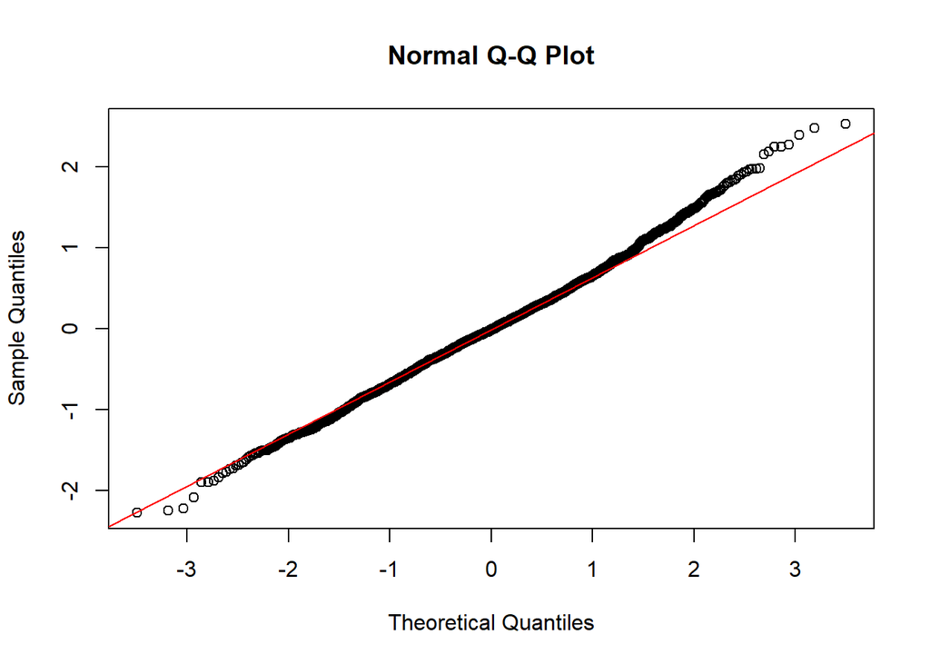

```r
residuals <- resid(aha_mnem_mdl_1)
qqnorm(residuals)
qqline(residuals, col = "red")
```

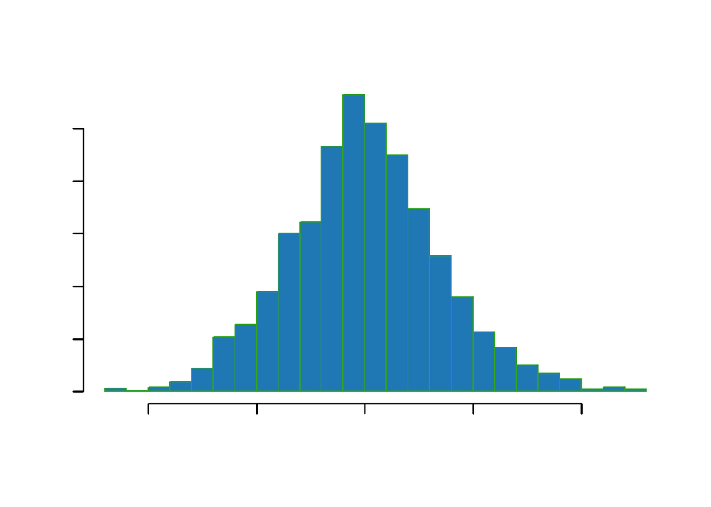

```r
hist(residuals,
     breaks = 30,
     main = "Гистограмма остатков",
     xlab = "Остатки",
     ylab = "Частота",
     col = "#1f78b4",          # Цвет столбцов
     border = "#33a02c",       # Цвет границ столбцов
     col.main = "white",       # Цвет заголовка
     col.lab = "white",        # Цвет подписей осей
     col.axis = "white",       # Цвет значений на осях
     lwd = 1.5)
```

```r
ks.test(residuals, "pnorm", mean = mean(residuals), sd = sd(residuals))
```

```
##
##  Asymptotic one-sample Kolmogorov-Smirnov test
##
## data:  residuals
## D = 0.024701, p-value = 0.1523
## alternative hypothesis: two-sided
```

```r
aha_mnem_mdl_1 %>% summ()
```

```
## MODEL INFO:
## Observations: 2110
## Dependent Variable: log_diff
## Type: Mixed effects linear regression
##
## MODEL FIT:
## AIC = 4691.77, BIC = 4720.05
## Pseudo-R² (fixed effects) = 0.01
## Pseudo-R² (total) = 0.14
##
## FIXED EFFECTS:
## -----------------------------------------------------------------------
##                                   Est.   S.E.   t val.      d.f.      p
## ------------------------------ ------- ------ -------- --------- ------
## (Intercept)                      -0.04   0.04    -0.90     95.65   0.37
## as.factor(Q1Aha.RESP)aha         -0.13   0.03    -3.97   2083.62   0.00
## -----------------------------------------------------------------------
##
## p values calculated using Satterthwaite d.f.
##
## RANDOM EFFECTS:
## ---------------------------------------
##     Group       Parameter    Std. Dev.
## ------------- ------------- -----------
##  Answer.Corr   (Intercept)     0.15
##      ID        (Intercept)     0.24
##   Residual                     0.71
## ---------------------------------------
##
## Grouping variables:
## -------------------------------
##     Group      # groups   ICC
## ------------- ---------- ------
##  Answer.Corr      78      0.04
##      ID           55      0.10
## -------------------------------
```

### Вклад типа анаграммы в разницу между Ага

Анализ сделан с целью проверить гипотезу о том, что тип анаграммы влияет на мнемический выигрыш от инсайта.

```r
aha_mnem_mdl_2 <- lmer(log_diff ~ as.factor(Q1Aha.RESP)*Condition + (1|ID) + (1|Answer.Corr), aha_mnem_data, REML = FALSE)
aha_mnem_mdl_2 %>% summary()
```

```
## Linear mixed model fit by maximum likelihood . t-tests use Satterthwaite's
##   method [lmerModLmerTest]
## Formula: log_diff ~ as.factor(Q1Aha.RESP) * Condition + (1 | ID) + (1 |
##     Answer.Corr)
##    Data: aha_mnem_data
##
##      AIC      BIC   logLik deviance df.resid
##   4694.9   4734.5  -2340.4   4680.9     2103
##
## Scaled residuals:
##     Min      1Q  Median      3Q     Max
## -3.2358 -0.6267 -0.0258  0.5928  3.5555
##
## Random effects:
##  Groups      Name        Variance Std.Dev.
##  Answer.Corr (Intercept) 0.02120  0.1456
##  ID          (Intercept) 0.05902  0.2429
##  Residual                0.50183  0.7084
## Number of obs: 2110, groups:  Answer.Corr, 78; ID, 55
##
## Fixed effects:
##                                       Estimate Std. Error         df t value
## (Intercept)                           -0.01916    0.04920  148.64866  -0.389
## as.factor(Q1Aha.RESP)aha              -0.14996    0.04646 2102.47572  -3.227
## Condition2                            -0.04055    0.04406 2038.38892  -0.920
## as.factor(Q1Aha.RESP)aha:Condition2    0.03110    0.06308 2058.82477   0.493
##                                     Pr(>|t|)
## (Intercept)                          0.69756
## as.factor(Q1Aha.RESP)aha             0.00127 **
## Condition2                           0.35758
## as.factor(Q1Aha.RESP)aha:Condition2  0.62206
## ---
## Signif. codes:  0 '***' 0.001 '**' 0.01 '*' 0.05 '.' 0.1 ' ' 1
##
## Correlation of Fixed Effects:
##               (Intr) as.(Q1A.RESP) Cndtn2
## as.(Q1A.RESP) -0.471
## Condition2    -0.448  0.485
## a.(Q1A.RESP):  0.319 -0.685        -0.708
```

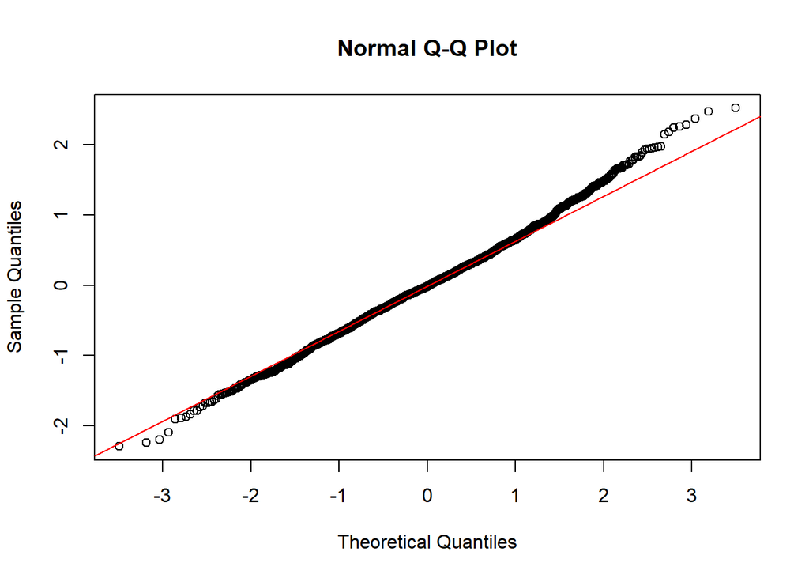

```r
residuals <- resid(aha_mnem_mdl_2)
qqnorm(residuals)
qqline(residuals, col = "red")
```

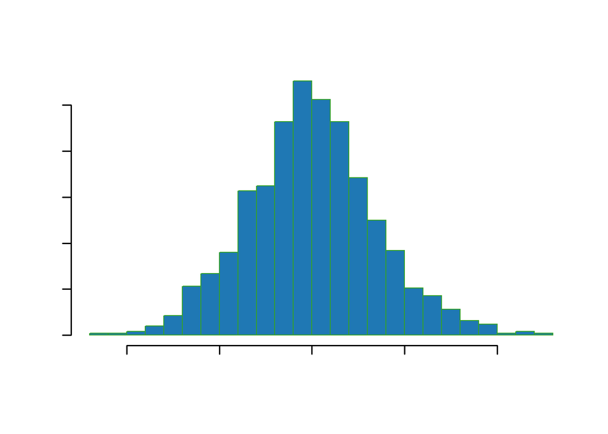

```r
hist(residuals,
     breaks = 30,
     main = "Гистограмма остатков",
     xlab = "Остатки",
     ylab = "Частота",
     col = "#1f78b4",          # Цвет столбцов
     border = "#33a02c",       # Цвет границ столбцов
     col.main = "white",       # Цвет заголовка
     col.lab = "white",        # Цвет подписей осей
     col.axis = "white",       # Цвет значений на осях
     lwd = 1.5)
```

```r
ks.test(residuals, "pnorm", mean = mean(residuals), sd = sd(residuals))
```

```
##
##  Asymptotic one-sample Kolmogorov-Smirnov test
##
## data:  residuals
## D = 0.025345, p-value = 0.1329
## alternative hypothesis: two-sided
```

# Анализ версий на втором этапе

В данном анализе проверялось предположение о том, что частота интрузий (т.е. случаев, когда слово-наводка из первого этапа упоминается участником в отчете про возникшие версии по ходу решения анаграммы на втором этапе) будет связана с решеённостью на первом этапе и наличие фиксированности.

### Сравнение вероятности возникновения версий-интрузий между группами.

В данном анализе проверялось предположение о том, что частота интрузий (т.е. случаев, когда слово-наводка из первого этапа упоминается участником в отчете про возникшие версии по ходу решения анаграммы на втором этапе) в контрольной группе будет отличаться от частоты интрузий в экспериментальной группе, в связи с тем, что только в экспериментальной группе на первом этапе половина анаграмм предъявлялась с наводкой, которую необходимо было преодолеть. При этом ожидалось два эффекта: в случае, если участник ЭГ не решил анаграмму с наводкой на первом этапе, вероятность ее возникновения в качестве версий-интрузий будет выше, чем в контрольной группе, а если участник ЭГ успешно преодолел фиксацию на наводке и нашел правильное решение анаграммы, то вероятность возникновения слова-наводки в качестве версии будет значимо ниже, чем в КГ (эффект подавления, вызванного решением задачи).

#### Отсев

```r
full_data$dropout_intr <- 0
full_data[!is.na(full_data$dropout_1) & full_data$dropout_1 == 1, ]$dropout_intr <- 1
full_data[!is.na(full_data$dropout_2) & full_data$dropout_2 == 1, ]$dropout_intr <- 1
if(nrow(full_data[!is.na(full_data$exclude) & full_data$exclude == 1, ]) > 0)
  full_data[!is.na(full_data$exclude) & full_data$exclude == 1, ]$dropout_intr <- 1

full_data$dropout_intr  %>%  table()
```

```
## .
##    0    1
## 9301  371
```

```r
full_data %>%
  filter(dropout_intr == 0) -> vers_btwn_gr_data
```

#### Кол-во проб после отсева

```r
vers_btwn_gr_data %>% nrow()
```

```
## [1] 9301
```

#### Анализ частот

частоты

```r
vers_btwn_gr_data %>%
  select(intrusion, group) %>%
  table()
```

```
##          group
## intrusion контроль эксп
##         0     3514 4038
##         1      776  973
```

```r
vers_btwn_gr_data %>%
  select(intrusion, group) %>%
  table() %>%
  chisq.test()
```

```
##
##  Pearson's Chi-squared test with Yates' continuity correction
##
## data:  .
## X-squared = 2.5862, df = 1, p-value = 0.1078
```

#### Смешанные модели

```r
vers_btwn_gr_data$intrusion <- vers_btwn_gr_data$intrusion %>% as.factor()
vers_btwn_gr_data$group <- vers_btwn_gr_data$group %>% as.factor()

vers_btwn_mdl_1 <- glmer(
                          intrusion ~ group + (1|ID) + (1|Answer.Corr),
                          vers_btwn_gr_data,
                          family = binomial)
vers_btwn_mdl_1 %>% summary()
```

```
## Generalized linear mixed model fit by maximum likelihood (Laplace
##   Approximation) [glmerMod]
##  Family: binomial  ( logit )
## Formula: intrusion ~ group + (1 | ID) + (1 | Answer.Corr)
##    Data: vers_btwn_gr_data
##
##      AIC      BIC   logLik deviance df.resid
##   8015.3   8043.9  -4003.7   8007.3     9297
##
## Scaled residuals:
##     Min      1Q  Median      3Q     Max
## -1.5749 -0.4772 -0.3273 -0.1974  8.0268
##
## Random effects:
##  Groups      Name        Variance Std.Dev.
##  ID          (Intercept) 0.1946   0.4411
##  Answer.Corr (Intercept) 1.0018   1.0009
## Number of obs: 9301, groups:  ID, 120; Answer.Corr, 78
##
## Fixed effects:
##             Estimate Std. Error z value Pr(>|z|)
## (Intercept) -1.84283    0.13654 -13.496   <2e-16 ***
## groupэксп    0.09717    0.09945   0.977    0.329
## ---
## Signif. codes:  0 '***' 0.001 '**' 0.01 '*' 0.05 '.' 0.1 ' ' 1
##
## Correlation of Fixed Effects:
```

```
##           (Intr)
## groupэксп -0.397
```

```r
vers_btwn_mdl_1 %>% summ()
```

```
## MODEL INFO:
## Observations: 9301
## Dependent Variable: intrusion
## Type: Mixed effects generalized linear regression
## Error Distribution: binomial
## Link function: logit
##
## MODEL FIT:
## AIC = 8015.33, BIC = 8043.88
## Pseudo-R² (fixed effects) = 0.00
## Pseudo-R² (total) = 0.27
##
## FIXED EFFECTS:
## ------------------------------------------------
##                      Est.   S.E.   z val.      p
## ----------------- ------- ------ -------- ------
## (Intercept)         -1.84   0.14   -13.50   0.00
## groupэксп            0.10   0.10     0.98   0.33
## ------------------------------------------------
##
## RANDOM EFFECTS:
## ---------------------------------------
##     Group       Parameter    Std. Dev.
## ------------- ------------- -----------
##      ID        (Intercept)     0.44
##  Answer.Corr   (Intercept)     1.00
## ---------------------------------------
##
## Grouping variables:
## -------------------------------
##     Group      # groups   ICC
## ------------- ---------- ------
##      ID          120      0.04
##  Answer.Corr      78      0.22
## -------------------------------
```

### Сравнение вероятности возникновения интрузий между правильно решенными на первом этапами анаграммами в экспериментальной группе и с контрольной группой

Ожидалось, что на вероятность возникновения интрузий в экспериментальной группе будет влиять успешность решения анаграмм на первом этапе. Для проверки этого предположения было выполнено два анализа.

#### Отсев

```r
vers_btwn_gr_data %>% filter((Accuracy == 1 | is.na(Accuracy))) -> r_vers_btwn_gr_data
```

#### Кол-во проб

```r
r_vers_btwn_gr_data %>% nrow()
```

```
## [1] 7315
```

По группам

```r
r_vers_btwn_gr_data$group %>% table()
```

```
## .
## контроль     эксп
##     4290     3025
```

По группам - правильность на втором этапе

```r
table(r_vers_btwn_gr_data$group, r_vers_btwn_gr_data$Accuracy2)
```

```
##
##               0    1
##   контроль 1803 2487
##   эксп      523 2502
```

#### Смешанные модели

В связи с тем, что количество проб в группах не является пропорциональным, для анализа были использованы только смешанные регрессионные модели.

```r
r_vers_btwn_gr_mdl_1 <- glmer(
                              intrusion ~ group + (1|ID) + (1|Answer.Corr),
                              r_vers_btwn_gr_data,
                              family = binomial)
summary(r_vers_btwn_gr_mdl_1)
```

```
## Generalized linear mixed model fit by maximum likelihood (Laplace
##   Approximation) [glmerMod]
##  Family: binomial  ( logit )
## Formula: intrusion ~ group + (1 | ID) + (1 | Answer.Corr)
##    Data: r_vers_btwn_gr_data
##
##      AIC      BIC   logLik deviance df.resid
##   6112.4   6140.0  -3052.2   6104.4     7311
##
## Scaled residuals:
##     Min      1Q  Median      3Q     Max
## -1.5949 -0.4562 -0.3179 -0.2023  7.9547
##
## Random effects:
##  Groups      Name        Variance Std.Dev.
##  ID          (Intercept) 0.1733   0.4163
##  Answer.Corr (Intercept) 1.0023   1.0012
## Number of obs: 7315, groups:  ID, 120; Answer.Corr, 78
##
## Fixed effects:
##             Estimate Std. Error z value Pr(>|z|)
## (Intercept) -1.84100    0.13556 -13.580   <2e-16 ***
## groupэксп   -0.07061    0.10279  -0.687    0.492
## ---
## Signif. codes:  0 '***' 0.001 '**' 0.01 '*' 0.05 '.' 0.1 ' ' 1
##
## Correlation of Fixed Effects:
```

```
##           (Intr)
## groupэксп -0.357
```

```r
r_vers_btwn_gr_mdl_1 %>% summ()
```

```
## MODEL INFO:
## Observations: 7315
## Dependent Variable: intrusion
## Type: Mixed effects generalized linear regression
## Error Distribution: binomial
## Link function: logit
##
## MODEL FIT:
## AIC = 6112.43, BIC = 6140.02
## Pseudo-R² (fixed effects) = 0.00
## Pseudo-R² (total) = 0.26
##
## FIXED EFFECTS:
## ------------------------------------------------
##                      Est.   S.E.   z val.      p
## ----------------- ------- ------ -------- ------
## (Intercept)         -1.84   0.14   -13.58   0.00
## groupэксп           -0.07   0.10    -0.69   0.49
## ------------------------------------------------
##
## RANDOM EFFECTS:
## ---------------------------------------
##     Group       Parameter    Std. Dev.
## ------------- ------------- -----------
##      ID        (Intercept)     0.42
##  Answer.Corr   (Intercept)     1.00
## ---------------------------------------
##
## Grouping variables:
## -------------------------------
##     Group      # groups   ICC
## ------------- ---------- ------
##      ID          120      0.04
##  Answer.Corr      78      0.22
## -------------------------------
```

#### Бутстрап

```r
for (i in c(1:20)) {
  r_vers_btwn_gr_data$dropout_intr_boot <- 1
  r_vers_btwn_gr_data[r_vers_btwn_gr_data$group == "контроль" & r_vers_btwn_gr_data$Accuracy2 == 0, ]$dropout_intr_boot <- sample(c(sample(c(1), 500, replace = TRUE), sample(c(0), 1303, replace = TRUE)))


  r_vers_btwn_gr_mdl_2 <- glmer(
                                intrusion ~ group + (1|ID) + (1|Answer.Corr),
                                r_vers_btwn_gr_data %>% filter(dropout_intr_boot == 1),
                                family = binomial)
  summary(r_vers_btwn_gr_mdl_2) %>% print()

}
```

```
## Generalized linear mixed model fit by maximum likelihood (Laplace
##   Approximation) [glmerMod]
##  Family: binomial  ( logit )
## Formula: intrusion ~ group + (1 | ID) + (1 | Answer.Corr)
##    Data: r_vers_btwn_gr_data %>% filter(dropout_intr_boot == 1)
##
##      AIC      BIC   logLik deviance df.resid
##   4751.8   4778.6  -2371.9   4743.8     6008
##
## Scaled residuals:
##     Min      1Q  Median      3Q     Max
## -1.5196 -0.4364 -0.2938 -0.1868  7.7888
##
## Random effects:
##  Groups      Name        Variance Std.Dev.
##  ID          (Intercept) 0.1948   0.4414
##  Answer.Corr (Intercept) 1.1382   1.0669
## Number of obs: 6012, groups:  ID, 120; Answer.Corr, 78
##
## Fixed effects:
##             Estimate Std. Error z value Pr(>|z|)
## (Intercept)  -2.0958     0.1490 -14.069   <2e-16 ***
## groupэксп     0.1438     0.1118   1.286    0.198
## ---
## Signif. codes:  0 '***' 0.001 '**' 0.01 '*' 0.05 '.' 0.1 ' ' 1
##
## Correlation of Fixed Effects:
```

```
##           (Intr)
## groupэксп -0.398
## Generalized linear mixed model fit by maximum likelihood (Laplace
##   Approximation) [glmerMod]
##  Family: binomial  ( logit )
## Formula: intrusion ~ group + (1 | ID) + (1 | Answer.Corr)
##    Data: r_vers_btwn_gr_data %>% filter(dropout_intr_boot == 1)
##
##      AIC      BIC   logLik deviance df.resid
##   4726.1   4752.9  -2359.1   4718.1     6008
##
## Scaled residuals:
##     Min      1Q  Median      3Q     Max
## -1.5185 -0.4314 -0.2884 -0.1865  8.0959
##
## Random effects:
##  Groups      Name        Variance Std.Dev.
##  ID          (Intercept) 0.2124   0.4609
##  Answer.Corr (Intercept) 1.1759   1.0844
## Number of obs: 6012, groups:  ID, 120; Answer.Corr, 78
##
## Fixed effects:
##             Estimate Std. Error z value Pr(>|z|)
## (Intercept)  -2.1296     0.1521 -14.002   <2e-16 ***
## groupэксп     0.1573     0.1147   1.371     0.17
## ---
## Signif. codes:  0 '***' 0.001 '**' 0.01 '*' 0.05 '.' 0.1 ' ' 1
##
## Correlation of Fixed Effects:
```

```
##           (Intr)
## groupэксп -0.402
## Generalized linear mixed model fit by maximum likelihood (Laplace
##   Approximation) [glmerMod]
##  Family: binomial  ( logit )
## Formula: intrusion ~ group + (1 | ID) + (1 | Answer.Corr)
##    Data: r_vers_btwn_gr_data %>% filter(dropout_intr_boot == 1)
##
##      AIC      BIC   logLik deviance df.resid
##   4691.2   4718.0  -2341.6   4683.2     6008
##
## Scaled residuals:
##     Min      1Q  Median      3Q     Max
## -1.5210 -0.4287 -0.2902 -0.1806  7.9311
##
## Random effects:
##  Groups      Name        Variance Std.Dev.
##  ID          (Intercept) 0.2054   0.4532
##  Answer.Corr (Intercept) 1.1759   1.0844
## Number of obs: 6012, groups:  ID, 120; Answer.Corr, 78
##
## Fixed effects:
##             Estimate Std. Error z value Pr(>|z|)
## (Intercept)  -2.1620     0.1520 -14.224   <2e-16 ***
## groupэксп     0.1882     0.1140   1.652   0.0986 .
## ---
## Signif. codes:  0 '***' 0.001 '**' 0.01 '*' 0.05 '.' 0.1 ' ' 1
##
## Correlation of Fixed Effects:
```

```
##           (Intr)
## groupэксп -0.402
## Generalized linear mixed model fit by maximum likelihood (Laplace
##   Approximation) [glmerMod]
##  Family: binomial  ( logit )
## Formula: intrusion ~ group + (1 | ID) + (1 | Answer.Corr)
##    Data: r_vers_btwn_gr_data %>% filter(dropout_intr_boot == 1)
##
##      AIC      BIC   logLik deviance df.resid
##   4695.8   4722.6  -2343.9   4687.8     6008
##
## Scaled residuals:
##     Min      1Q  Median      3Q     Max
## -1.4814 -0.4304 -0.2868 -0.1790  8.1240
##
## Random effects:
##  Groups      Name        Variance Std.Dev.
##  ID          (Intercept) 0.2256   0.4749
##  Answer.Corr (Intercept) 1.2312   1.1096
## Number of obs: 6012, groups:  ID, 120; Answer.Corr, 78
##
## Fixed effects:
##             Estimate Std. Error z value Pr(>|z|)
## (Intercept)  -2.1725     0.1557  -13.95   <2e-16 ***
## groupэксп     0.1777     0.1170    1.52    0.129
## ---
## Signif. codes:  0 '***' 0.001 '**' 0.01 '*' 0.05 '.' 0.1 ' ' 1
##
## Correlation of Fixed Effects:
```

```
##           (Intr)
## groupэксп -0.402
## Generalized linear mixed model fit by maximum likelihood (Laplace
##   Approximation) [glmerMod]
##  Family: binomial  ( logit )
## Formula: intrusion ~ group + (1 | ID) + (1 | Answer.Corr)
##    Data: r_vers_btwn_gr_data %>% filter(dropout_intr_boot == 1)
##
##      AIC      BIC   logLik deviance df.resid
##   4737.8   4764.6  -2364.9   4729.8     6008
##
## Scaled residuals:
##     Min      1Q  Median      3Q     Max
## -1.6073 -0.4255 -0.2956 -0.1823  7.9909
##
## Random effects:
##  Groups      Name        Variance Std.Dev.
##  ID          (Intercept) 0.2058   0.4536
##  Answer.Corr (Intercept) 1.1582   1.0762
## Number of obs: 6012, groups:  ID, 120; Answer.Corr, 78
##
## Fixed effects:
##             Estimate Std. Error z value Pr(>|z|)
## (Intercept)  -2.1064     0.1507 -13.981   <2e-16 ***
## groupэксп     0.1392     0.1136   1.225     0.22
## ---
## Signif. codes:  0 '***' 0.001 '**' 0.01 '*' 0.05 '.' 0.1 ' ' 1
##
## Correlation of Fixed Effects:
```

```
##           (Intr)
## groupэксп -0.400
## Generalized linear mixed model fit by maximum likelihood (Laplace
##   Approximation) [glmerMod]
##  Family: binomial  ( logit )
## Formula: intrusion ~ group + (1 | ID) + (1 | Answer.Corr)
##    Data: r_vers_btwn_gr_data %>% filter(dropout_intr_boot == 1)
##
##      AIC      BIC   logLik deviance df.resid
##   4791.9   4818.7  -2391.9   4783.9     6008
##
## Scaled residuals:
##     Min      1Q  Median      3Q     Max
## -1.5246 -0.4345 -0.2988 -0.1907  7.8583
##
## Random effects:
##  Groups      Name        Variance Std.Dev.
##  ID          (Intercept) 0.2113   0.4597
##  Answer.Corr (Intercept) 1.1080   1.0526
## Number of obs: 6012, groups:  ID, 120; Answer.Corr, 78
##
## Fixed effects:
##             Estimate Std. Error z value Pr(>|z|)
## (Intercept)  -2.0763     0.1486 -13.969   <2e-16 ***
## groupэксп     0.1178     0.1141   1.032    0.302
## ---
## Signif. codes:  0 '***' 0.001 '**' 0.01 '*' 0.05 '.' 0.1 ' ' 1
##
## Correlation of Fixed Effects:
```

```
##           (Intr)
## groupэксп -0.407
## Generalized linear mixed model fit by maximum likelihood (Laplace
##   Approximation) [glmerMod]
##  Family: binomial  ( logit )
## Formula: intrusion ~ group + (1 | ID) + (1 | Answer.Corr)
##    Data: r_vers_btwn_gr_data %>% filter(dropout_intr_boot == 1)
##
##      AIC      BIC   logLik deviance df.resid
##   4631.3   4658.1  -2311.6   4623.3     6008
##
## Scaled residuals:
##     Min      1Q  Median      3Q     Max
## -1.5617 -0.4182 -0.2836 -0.1841  7.9836
##
## Random effects:
##  Groups      Name        Variance Std.Dev.
##  ID          (Intercept) 0.2185   0.4674
##  Answer.Corr (Intercept) 1.1897   1.0907
## Number of obs: 6012, groups:  ID, 120; Answer.Corr, 78
##
## Fixed effects:
##             Estimate Std. Error z value Pr(>|z|)
## (Intercept)  -2.2110     0.1536 -14.391   <2e-16 ***
## groupэксп     0.2239     0.1163   1.926   0.0541 .
## ---
## Signif. codes:  0 '***' 0.001 '**' 0.01 '*' 0.05 '.' 0.1 ' ' 1
##
## Correlation of Fixed Effects:
```

```
##           (Intr)
## groupэксп -0.407
## Generalized linear mixed model fit by maximum likelihood (Laplace
##   Approximation) [glmerMod]
##  Family: binomial  ( logit )
## Formula: intrusion ~ group + (1 | ID) + (1 | Answer.Corr)
##    Data: r_vers_btwn_gr_data %>% filter(dropout_intr_boot == 1)
##
##      AIC      BIC   logLik deviance df.resid
##   4676.8   4703.6  -2334.4   4668.8     6008
##
## Scaled residuals:
##     Min      1Q  Median      3Q     Max
## -1.6498 -0.4230 -0.2859 -0.1877  7.9063
##
## Random effects:
##  Groups      Name        Variance Std.Dev.
##  ID          (Intercept) 0.2115   0.4599
##  Answer.Corr (Intercept) 1.1832   1.0878
## Number of obs: 6012, groups:  ID, 120; Answer.Corr, 78
##
## Fixed effects:
##             Estimate Std. Error z value Pr(>|z|)
## (Intercept)  -2.1693     0.1527  -14.21   <2e-16 ***
## groupэксп     0.1943     0.1150    1.69    0.091 .
## ---
## Signif. codes:  0 '***' 0.001 '**' 0.01 '*' 0.05 '.' 0.1 ' ' 1
##
## Correlation of Fixed Effects:
```

```
##           (Intr)
## groupэксп -0.403
## Generalized linear mixed model fit by maximum likelihood (Laplace
##   Approximation) [glmerMod]
##  Family: binomial  ( logit )
## Formula: intrusion ~ group + (1 | ID) + (1 | Answer.Corr)
##    Data: r_vers_btwn_gr_data %>% filter(dropout_intr_boot == 1)
##
##      AIC      BIC   logLik deviance df.resid
##   4733.1   4759.9  -2362.5   4725.1     6008
##
## Scaled residuals:
##     Min      1Q  Median      3Q     Max
## -1.4529 -0.4318 -0.2925 -0.1841  8.0258
##
## Random effects:
##  Groups      Name        Variance Std.Dev.
##  ID          (Intercept) 0.2205   0.4696
##  Answer.Corr (Intercept) 1.1437   1.0694
## Number of obs: 6012, groups:  ID, 120; Answer.Corr, 78
##
## Fixed effects:
##             Estimate Std. Error z value Pr(>|z|)
## (Intercept)  -2.1272     0.1511 -14.075   <2e-16 ***
## groupэксп     0.1528     0.1159   1.319    0.187
## ---
## Signif. codes:  0 '***' 0.001 '**' 0.01 '*' 0.05 '.' 0.1 ' ' 1
##
## Correlation of Fixed Effects:
```

```
##           (Intr)
## groupэксп -0.408
## Generalized linear mixed model fit by maximum likelihood (Laplace
##   Approximation) [glmerMod]
##  Family: binomial  ( logit )
## Formula: intrusion ~ group + (1 | ID) + (1 | Answer.Corr)
##    Data: r_vers_btwn_gr_data %>% filter(dropout_intr_boot == 1)
##
##      AIC      BIC   logLik deviance df.resid
##   4728.9   4755.7  -2360.5   4720.9     6008
##
## Scaled residuals:
##     Min      1Q  Median      3Q     Max
## -1.5649 -0.4306 -0.2906 -0.1841  7.9572
##
## Random effects:
##  Groups      Name        Variance Std.Dev.
##  ID          (Intercept) 0.206    0.4539
##  Answer.Corr (Intercept) 1.181    1.0868
## Number of obs: 6012, groups:  ID, 120; Answer.Corr, 78
##
## Fixed effects:
##             Estimate Std. Error z value Pr(>|z|)
## (Intercept)  -2.1287     0.1519 -14.018   <2e-16 ***
## groupэксп     0.1540     0.1136   1.355    0.175
## ---
## Signif. codes:  0 '***' 0.001 '**' 0.01 '*' 0.05 '.' 0.1 ' ' 1
##
## Correlation of Fixed Effects:
```

```
##           (Intr)
## groupэксп -0.398
## Generalized linear mixed model fit by maximum likelihood (Laplace
##   Approximation) [glmerMod]
##  Family: binomial  ( logit )
## Formula: intrusion ~ group + (1 | ID) + (1 | Answer.Corr)
##    Data: r_vers_btwn_gr_data %>% filter(dropout_intr_boot == 1)
##
##      AIC      BIC   logLik deviance df.resid
##   4741.6   4768.4  -2366.8   4733.6     6008
##
## Scaled residuals:
##     Min      1Q  Median      3Q     Max
## -1.5958 -0.4367 -0.2910 -0.1855  7.9737
##
## Random effects:
##  Groups      Name        Variance Std.Dev.
##  ID          (Intercept) 0.2365   0.4863
##  Answer.Corr (Intercept) 1.1256   1.0609
## Number of obs: 6012, groups:  ID, 120; Answer.Corr, 78
##
## Fixed effects:
##             Estimate Std. Error z value Pr(>|z|)
## (Intercept)  -2.1361     0.1516  -14.09   <2e-16 ***
## groupэксп     0.1681     0.1184    1.42    0.156
## ---
## Signif. codes:  0 '***' 0.001 '**' 0.01 '*' 0.05 '.' 0.1 ' ' 1
##
## Correlation of Fixed Effects:
```

```
##           (Intr)
## groupэксп -0.418
## Generalized linear mixed model fit by maximum likelihood (Laplace
##   Approximation) [glmerMod]
##  Family: binomial  ( logit )
## Formula: intrusion ~ group + (1 | ID) + (1 | Answer.Corr)
##    Data: r_vers_btwn_gr_data %>% filter(dropout_intr_boot == 1)
##
##      AIC      BIC   logLik deviance df.resid
##   4670.7   4697.5  -2331.3   4662.7     6008
##
## Scaled residuals:
##     Min      1Q  Median      3Q     Max
## -1.6061 -0.4283 -0.2838 -0.1799  8.0205
##
## Random effects:
##  Groups      Name        Variance Std.Dev.
##  ID          (Intercept) 0.2371   0.487
##  Answer.Corr (Intercept) 1.1985   1.095
## Number of obs: 6012, groups:  ID, 120; Answer.Corr, 78
##
## Fixed effects:
##             Estimate Std. Error z value Pr(>|z|)
## (Intercept)  -2.1924     0.1551 -14.133   <2e-16 ***
## groupэксп     0.2073     0.1189   1.743   0.0813 .
## ---
## Signif. codes:  0 '***' 0.001 '**' 0.01 '*' 0.05 '.' 0.1 ' ' 1
##
## Correlation of Fixed Effects:
```

```
##           (Intr)
## groupэксп -0.412
## Generalized linear mixed model fit by maximum likelihood (Laplace
##   Approximation) [glmerMod]
##  Family: binomial  ( logit )
## Formula: intrusion ~ group + (1 | ID) + (1 | Answer.Corr)
##    Data: r_vers_btwn_gr_data %>% filter(dropout_intr_boot == 1)
##
##      AIC      BIC   logLik deviance df.resid
##   4689.7   4716.5  -2340.8   4681.7     6008
##
## Scaled residuals:
##     Min      1Q  Median      3Q     Max
## -1.4982 -0.4278 -0.2849 -0.1786  8.1045
##
## Random effects:
##  Groups      Name        Variance Std.Dev.
##  ID          (Intercept) 0.2344   0.4841
##  Answer.Corr (Intercept) 1.2163   1.1028
## Number of obs: 6012, groups:  ID, 120; Answer.Corr, 78
##
## Fixed effects:
##             Estimate Std. Error z value Pr(>|z|)
## (Intercept)  -2.1687     0.1555 -13.947   <2e-16 ***
## groupэксп     0.1757     0.1182   1.486    0.137
## ---
## Signif. codes:  0 '***' 0.001 '**' 0.01 '*' 0.05 '.' 0.1 ' ' 1
##
## Correlation of Fixed Effects:
```

```
##           (Intr)
## groupэксп -0.407
## Generalized linear mixed model fit by maximum likelihood (Laplace
##   Approximation) [glmerMod]
##  Family: binomial  ( logit )
## Formula: intrusion ~ group + (1 | ID) + (1 | Answer.Corr)
##    Data: r_vers_btwn_gr_data %>% filter(dropout_intr_boot == 1)
##
##      AIC      BIC   logLik deviance df.resid
##   4771.5   4798.3  -2381.8   4763.5     6008
##
## Scaled residuals:
##     Min      1Q  Median      3Q     Max
## -1.5539 -0.4316 -0.2987 -0.1942  7.7533
##
## Random effects:
##  Groups      Name        Variance Std.Dev.
##  ID          (Intercept) 0.1954   0.442
##  Answer.Corr (Intercept) 1.0943   1.046
## Number of obs: 6012, groups:  ID, 120; Answer.Corr, 78
##
## Fixed effects:
##             Estimate Std. Error z value Pr(>|z|)
## (Intercept)  -2.0680     0.1468 -14.087   <2e-16 ***
## groupэксп     0.1188     0.1118   1.062    0.288
## ---
## Signif. codes:  0 '***' 0.001 '**' 0.01 '*' 0.05 '.' 0.1 ' ' 1
##
## Correlation of Fixed Effects:
```

```
##           (Intr)
## groupэксп -0.402
## Generalized linear mixed model fit by maximum likelihood (Laplace
##   Approximation) [glmerMod]
##  Family: binomial  ( logit )
## Formula: intrusion ~ group + (1 | ID) + (1 | Answer.Corr)
##    Data: r_vers_btwn_gr_data %>% filter(dropout_intr_boot == 1)
##
##      AIC      BIC   logLik deviance df.resid
##   4731.8   4758.6  -2361.9   4723.8     6008
##
## Scaled residuals:
##     Min      1Q  Median      3Q     Max
## -1.4408 -0.4293 -0.2922 -0.1886  7.8148
##
## Random effects:
##  Groups      Name        Variance Std.Dev.
##  ID          (Intercept) 0.1793   0.4234
##  Answer.Corr (Intercept) 1.1746   1.0838
## Number of obs: 6012, groups:  ID, 120; Answer.Corr, 78
##
## Fixed effects:
##             Estimate Std. Error z value Pr(>|z|)
## (Intercept)  -2.1150     0.1498 -14.115   <2e-16 ***
## groupэксп     0.1357     0.1094   1.241    0.215
## ---
## Signif. codes:  0 '***' 0.001 '**' 0.01 '*' 0.05 '.' 0.1 ' ' 1
##
## Correlation of Fixed Effects:
```

```
##           (Intr)
## groupэксп -0.386
## Generalized linear mixed model fit by maximum likelihood (Laplace
##   Approximation) [glmerMod]
##  Family: binomial  ( logit )
## Formula: intrusion ~ group + (1 | ID) + (1 | Answer.Corr)
##    Data: r_vers_btwn_gr_data %>% filter(dropout_intr_boot == 1)
##
##      AIC      BIC   logLik deviance df.resid
##   4725.9   4752.7  -2359.0   4717.9     6008
##
## Scaled residuals:
##     Min      1Q  Median      3Q     Max
## -1.5793 -0.4335 -0.2890 -0.1807  8.0082
##
## Random effects:
##  Groups      Name        Variance Std.Dev.
##  ID          (Intercept) 0.2122   0.4607
##  Answer.Corr (Intercept) 1.2211   1.1050
## Number of obs: 6012, groups:  ID, 120; Answer.Corr, 78
##
## Fixed effects:
##             Estimate Std. Error z value Pr(>|z|)
## (Intercept)  -2.1387     0.1541  -13.88   <2e-16 ***
## groupэксп     0.1525     0.1146    1.33    0.183
## ---
## Signif. codes:  0 '***' 0.001 '**' 0.01 '*' 0.05 '.' 0.1 ' ' 1
##
## Correlation of Fixed Effects:
```

```
##           (Intr)
## groupэксп -0.396
## Generalized linear mixed model fit by maximum likelihood (Laplace
##   Approximation) [glmerMod]
##  Family: binomial  ( logit )
## Formula: intrusion ~ group + (1 | ID) + (1 | Answer.Corr)
##    Data: r_vers_btwn_gr_data %>% filter(dropout_intr_boot == 1)
##
##      AIC      BIC   logLik deviance df.resid
##   4727.0   4753.8  -2359.5   4719.0     6008
##
## Scaled residuals:
##    Min     1Q Median     3Q    Max
## -1.490 -0.429 -0.293 -0.193  7.785
##
## Random effects:
##  Groups      Name        Variance Std.Dev.
##  ID          (Intercept) 0.198    0.445
##  Answer.Corr (Intercept) 1.104    1.051
## Number of obs: 6012, groups:  ID, 120; Answer.Corr, 78
##
## Fixed effects:
##             Estimate Std. Error z value Pr(>|z|)
## (Intercept)  -2.1340     0.1479 -14.427   <2e-16 ***
## groupэксп     0.1803     0.1124   1.604    0.109
## ---
## Signif. codes:  0 '***' 0.001 '**' 0.01 '*' 0.05 '.' 0.1 ' ' 1
##
## Correlation of Fixed Effects:
```

```
##           (Intr)
## groupэксп -0.405
## Generalized linear mixed model fit by maximum likelihood (Laplace
##   Approximation) [glmerMod]
##  Family: binomial  ( logit )
## Formula: intrusion ~ group + (1 | ID) + (1 | Answer.Corr)
##    Data: r_vers_btwn_gr_data %>% filter(dropout_intr_boot == 1)
##
##      AIC      BIC   logLik deviance df.resid
##   4758.7   4785.5  -2375.4   4750.7     6008
##
## Scaled residuals:
##     Min      1Q  Median      3Q     Max
## -1.5960 -0.4318 -0.2964 -0.1896  7.8938
##
## Random effects:
##  Groups      Name        Variance Std.Dev.
##  ID          (Intercept) 0.2162   0.4649
##  Answer.Corr (Intercept) 1.1143   1.0556
## Number of obs: 6012, groups:  ID, 120; Answer.Corr, 78
##
## Fixed effects:
##             Estimate Std. Error z value Pr(>|z|)
## (Intercept)  -2.0936     0.1493 -14.026   <2e-16 ***
## groupэксп     0.1310     0.1151   1.138    0.255
## ---
## Signif. codes:  0 '***' 0.001 '**' 0.01 '*' 0.05 '.' 0.1 ' ' 1
##
## Correlation of Fixed Effects:
```

```
##           (Intr)
## groupэксп -0.409
## Generalized linear mixed model fit by maximum likelihood (Laplace
##   Approximation) [glmerMod]
##  Family: binomial  ( logit )
## Formula: intrusion ~ group + (1 | ID) + (1 | Answer.Corr)
##    Data: r_vers_btwn_gr_data %>% filter(dropout_intr_boot == 1)
##
##      AIC      BIC   logLik deviance df.resid
##   4738.5   4765.3  -2365.3   4730.5     6008
##
## Scaled residuals:
##     Min      1Q  Median      3Q     Max
## -1.6277 -0.4323 -0.2913 -0.1883  7.7772
##
## Random effects:
##  Groups      Name        Variance Std.Dev.
##  ID          (Intercept) 0.2125   0.461
##  Answer.Corr (Intercept) 1.1225   1.059
## Number of obs: 6012, groups:  ID, 120; Answer.Corr, 78
##
## Fixed effects:
##             Estimate Std. Error z value Pr(>|z|)
## (Intercept)  -2.1321     0.1497 -14.239   <2e-16 ***
## groupэксп     0.1657     0.1147   1.445    0.149
## ---
## Signif. codes:  0 '***' 0.001 '**' 0.01 '*' 0.05 '.' 0.1 ' ' 1
##
## Correlation of Fixed Effects:
```

```
##           (Intr)
## groupэксп -0.409
## Generalized linear mixed model fit by maximum likelihood (Laplace
##   Approximation) [glmerMod]
##  Family: binomial  ( logit )
## Formula: intrusion ~ group + (1 | ID) + (1 | Answer.Corr)
##    Data: r_vers_btwn_gr_data %>% filter(dropout_intr_boot == 1)
##
##      AIC      BIC   logLik deviance df.resid
##   4662.1   4688.9  -2327.0   4654.1     6008
##
## Scaled residuals:
##     Min      1Q  Median      3Q     Max
## -1.5725 -0.4230 -0.2867 -0.1837  7.9584
##
## Random effects:
##  Groups      Name        Variance Std.Dev.
##  ID          (Intercept) 0.1993   0.4464
##  Answer.Corr (Intercept) 1.1976   1.0943
## Number of obs: 6012, groups:  ID, 120; Answer.Corr, 78
##
## Fixed effects:
##             Estimate Std. Error z value Pr(>|z|)
## (Intercept)  -2.1932     0.1528 -14.352   <2e-16 ***
## groupэксп     0.2034     0.1131   1.798   0.0721 .
## ---
## Signif. codes:  0 '***' 0.001 '**' 0.01 '*' 0.05 '.' 0.1 ' ' 1
##
## Correlation of Fixed Effects:
```

```
##           (Intr)
## groupэксп -0.396
```

Итого в 20 случаях из 20 были получены не значимые результаты. Был выполнен биномиальный тест, для проверки случайности.

```r
binom.test(0, 20, 0.5, alternative = "greater")
```

```
##
##  Exact binomial test
##
## data:  0 and 20
## number of successes = 0, number of trials = 20, p-value = 1
## alternative hypothesis: true probability of success is greater than 0.5
## 95 percent confidence interval:
##  0 1
## sample estimates:
## probability of success
##                      0
```

#### Отсев

```r
vers_btwn_gr_data %>% filter((Accuracy == 0 | is.na(Accuracy))) -> w_vers_btwn_gr_data
```

#### Кол-во проб для анализа

```r
w_vers_btwn_gr_data %>% nrow()
```

```
## [1] 6276
```

По группам

```r
w_vers_btwn_gr_data$group %>% table()
```

```
## .
## контроль     эксп
##     4290     1986
```

```r
table(w_vers_btwn_gr_data$group, w_vers_btwn_gr_data$Accuracy2)
```

```
##
##               0    1
##   контроль 1803 2487
##   эксп     1191  795
```

#### Смешанные модели

```r
w_vers_btwn_gr_mdl_1 <- glmer(
                              intrusion ~ group + (1|ID) + (1|Answer.Corr),
                              w_vers_btwn_gr_data,
                              family = binomial)
summary(w_vers_btwn_gr_mdl_1)
```

```
## Generalized linear mixed model fit by maximum likelihood (Laplace
##   Approximation) [glmerMod]
##  Family: binomial  ( logit )
## Formula: intrusion ~ group + (1 | ID) + (1 | Answer.Corr)
##    Data: w_vers_btwn_gr_data
##
##      AIC      BIC   logLik deviance df.resid
##   5655.8   5682.7  -2823.9   5647.8     6272
##
## Scaled residuals:
##     Min      1Q  Median      3Q     Max
## -1.4239 -0.4960 -0.3498 -0.2076  5.7634
##
## Random effects:
##  Groups      Name        Variance Std.Dev.
##  ID          (Intercept) 0.1653   0.4066
##  Answer.Corr (Intercept) 0.9006   0.9490
## Number of obs: 6276, groups:  ID, 120; Answer.Corr, 78
##
## Fixed effects:
##             Estimate Std. Error z value Pr(>|z|)
## (Intercept)  -1.8113     0.1300 -13.928  < 2e-16 ***
## groupэксп     0.3581     0.1054   3.396 0.000683 ***
## ---
## Signif. codes:  0 '***' 0.001 '**' 0.01 '*' 0.05 '.' 0.1 ' ' 1
##
## Correlation of Fixed Effects:
```

```
##           (Intr)
## groupэксп -0.355
```

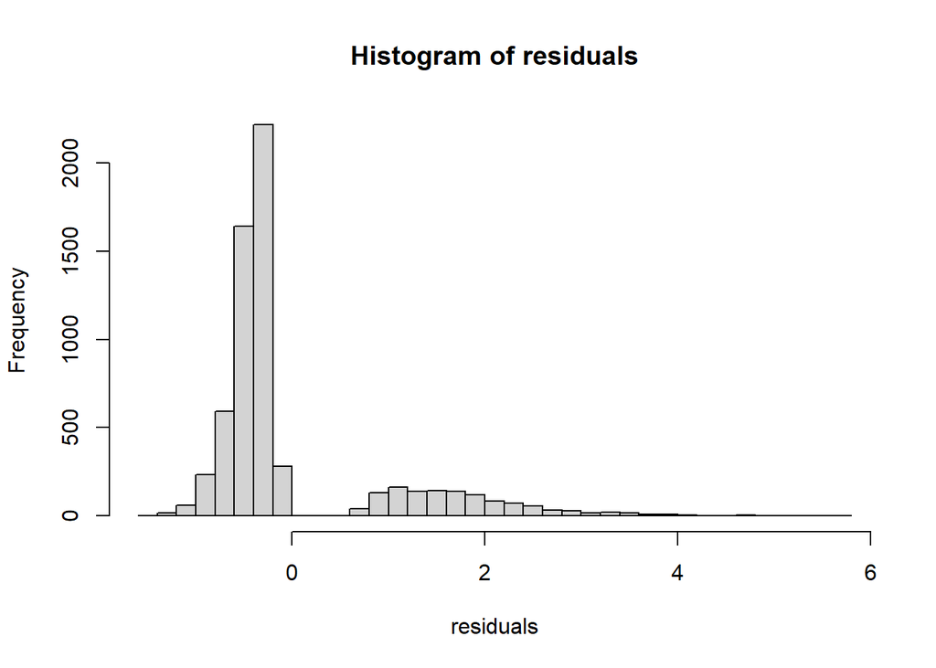

```r
residuals <- resid(w_vers_btwn_gr_mdl_1,  type = "pearson")
hist(residuals, breaks = 30)
```

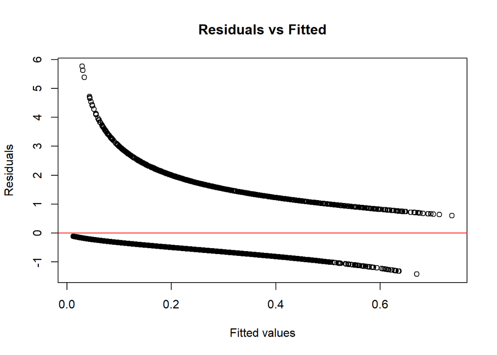

```r
plot(fitted(w_vers_btwn_gr_mdl_1), residuals, main = "Residuals vs Fitted", xlab = "Fitted values", ylab = "Residuals")
abline(h = 0, col = "red")
```

```r
w_vers_btwn_gr_mdl_1 %>% summ()
```

```
## MODEL INFO:
## Observations: 6276
## Dependent Variable: intrusion
## Type: Mixed effects generalized linear regression
## Error Distribution: binomial
## Link function: logit
##
## MODEL FIT:
## AIC = 5655.77, BIC = 5682.75
## Pseudo-R² (fixed effects) = 0.01
## Pseudo-R² (total) = 0.25
##
## FIXED EFFECTS:
## ------------------------------------------------
##                      Est.   S.E.   z val.      p
## ----------------- ------- ------ -------- ------
## (Intercept)         -1.81   0.13   -13.93   0.00
## groupэксп            0.36   0.11     3.40   0.00
## ------------------------------------------------
##
## RANDOM EFFECTS:
## ---------------------------------------
##     Group       Parameter    Std. Dev.
## ------------- ------------- -----------
##      ID        (Intercept)     0.41
##  Answer.Corr   (Intercept)     0.95
## ---------------------------------------
##
## Grouping variables:
## -------------------------------
##     Group      # groups   ICC
## ------------- ---------- ------
##      ID          120      0.04
##  Answer.Corr      78      0.21
## -------------------------------
```

#### Бутстрап

```r
for (i in c(1:20)) {
  w_vers_btwn_gr_data$dropout_intr_boot <- 1

  w_vers_btwn_gr_data[w_vers_btwn_gr_data$group == "контроль" & w_vers_btwn_gr_data$Accuracy2 == 1, ]$dropout_intr_boot <- sample(
    c(sample(c(1), 800,  replace = TRUE),
      sample(c(0), 1687, replace = TRUE))
  )

  w_vers_btwn_gr_data[w_vers_btwn_gr_data$group == "контроль" & w_vers_btwn_gr_data$Accuracy2 == 0, ]$dropout_intr_boot <- sample(
    c(sample(c(1), 1200, replace = TRUE),
      sample(c(0), 603, replace = TRUE))
    )

  print(table(w_vers_btwn_gr_data$group, w_vers_btwn_gr_data$Accuracy2))

  w_vers_btwn_gr_mdl_2 <- glmer(
                                intrusion ~ group + (1|ID) + (1|Answer.Corr),
                                w_vers_btwn_gr_data %>% filter(dropout_intr_boot == 1),
                                family = binomial)
  summary(w_vers_btwn_gr_mdl_2) %>% print()

}
```

```
##
##               0    1
##   контроль 1803 2487
##   эксп     1191  795
## Generalized linear mixed model fit by maximum likelihood (Laplace
##   Approximation) [glmerMod]
##  Family: binomial  ( logit )
## Formula: intrusion ~ group + (1 | ID) + (1 | Answer.Corr)
##    Data: w_vers_btwn_gr_data %>% filter(dropout_intr_boot == 1)
##
##      AIC      BIC   logLik deviance df.resid
##   3811.5   3836.7  -1901.8   3803.5     3982
##
## Scaled residuals:
##     Min      1Q  Median      3Q     Max
## -1.3112 -0.5238 -0.3656 -0.2161  4.8901
##
## Random effects:
##  Groups      Name        Variance Std.Dev.
##  ID          (Intercept) 0.1589   0.3987
##  Answer.Corr (Intercept) 0.8849   0.9407
## Number of obs: 3986, groups:  ID, 120; Answer.Corr, 78
##
## Fixed effects:
##             Estimate Std. Error z value Pr(>|z|)
## (Intercept)  -1.6678     0.1366  -12.21   <2e-16 ***
## groupэксп     0.2321     0.1127    2.06   0.0394 *
## ---
## Signif. codes:  0 '***' 0.001 '**' 0.01 '*' 0.05 '.' 0.1 ' ' 1
##
## Correlation of Fixed Effects:
```

```
##           (Intr)
## groupэксп -0.424
##
##               0    1
##   контроль 1803 2487
##   эксп     1191  795
## Generalized linear mixed model fit by maximum likelihood (Laplace
##   Approximation) [glmerMod]
##  Family: binomial  ( logit )
## Formula: intrusion ~ group + (1 | ID) + (1 | Answer.Corr)
##    Data: w_vers_btwn_gr_data %>% filter(dropout_intr_boot == 1)
##
##      AIC      BIC   logLik deviance df.resid
##   3901.2   3926.4  -1946.6   3893.2     3982
##
## Scaled residuals:
##     Min      1Q  Median      3Q     Max
## -1.3167 -0.5392 -0.3803 -0.2220  4.7293
##
## Random effects:
##  Groups      Name        Variance Std.Dev.
##  ID          (Intercept) 0.1650   0.4062
##  Answer.Corr (Intercept) 0.7746   0.8801
## Number of obs: 3986, groups:  ID, 120; Answer.Corr, 78
##
## Fixed effects:
##             Estimate Std. Error z value Pr(>|z|)
## (Intercept)  -1.5699     0.1306 -12.021   <2e-16 ***
## groupэксп     0.1548     0.1125   1.375    0.169
## ---
## Signif. codes:  0 '***' 0.001 '**' 0.01 '*' 0.05 '.' 0.1 ' ' 1
##
## Correlation of Fixed Effects:
```

```
##           (Intr)
## groupэксп -0.438
##
##               0    1
##   контроль 1803 2487
##   эксп     1191  795
## Generalized linear mixed model fit by maximum likelihood (Laplace
##   Approximation) [glmerMod]
##  Family: binomial  ( logit )
## Formula: intrusion ~ group + (1 | ID) + (1 | Answer.Corr)
##    Data: w_vers_btwn_gr_data %>% filter(dropout_intr_boot == 1)
##
##      AIC      BIC   logLik deviance df.resid
##   3833.2   3858.4  -1912.6   3825.2     3982
##
## Scaled residuals:
##     Min      1Q  Median      3Q     Max
## -1.3606 -0.5246 -0.3684 -0.2110  4.7052
##
## Random effects:
##  Groups      Name        Variance Std.Dev.
##  ID          (Intercept) 0.1774   0.4212
##  Answer.Corr (Intercept) 0.8731   0.9344
## Number of obs: 3986, groups:  ID, 120; Answer.Corr, 78
##
## Fixed effects:
##             Estimate Std. Error z value Pr(>|z|)
## (Intercept)  -1.6505     0.1372  -12.03   <2e-16 ***
## groupэксп     0.2030     0.1153    1.76   0.0784 .
## ---
## Signif. codes:  0 '***' 0.001 '**' 0.01 '*' 0.05 '.' 0.1 ' ' 1
##
## Correlation of Fixed Effects:
```

```
##           (Intr)
## groupэксп -0.431
##
##               0    1
##   контроль 1803 2487
##   эксп     1191  795
## Generalized linear mixed model fit by maximum likelihood (Laplace
##   Approximation) [glmerMod]
##  Family: binomial  ( logit )
## Formula: intrusion ~ group + (1 | ID) + (1 | Answer.Corr)
##    Data: w_vers_btwn_gr_data %>% filter(dropout_intr_boot == 1)
##
##      AIC      BIC   logLik deviance df.resid
##   3799.5   3824.6  -1895.7   3791.5     3982
##
## Scaled residuals:
##     Min      1Q  Median      3Q     Max
## -1.3963 -0.5230 -0.3657 -0.2008  4.9734
##
## Random effects:
##  Groups      Name        Variance Std.Dev.
##  ID          (Intercept) 0.1662   0.4077
##  Answer.Corr (Intercept) 0.9644   0.9820
## Number of obs: 3986, groups:  ID, 120; Answer.Corr, 78
##
## Fixed effects:
##             Estimate Std. Error z value Pr(>|z|)
## (Intercept)  -1.6866     0.1412 -11.949   <2e-16 ***
## groupэксп     0.2204     0.1139   1.935    0.053 .
## ---
## Signif. codes:  0 '***' 0.001 '**' 0.01 '*' 0.05 '.' 0.1 ' ' 1
##
## Correlation of Fixed Effects:
```

```
##           (Intr)
## groupэксп -0.414
##
##               0    1
##   контроль 1803 2487
##   эксп     1191  795
## Generalized linear mixed model fit by maximum likelihood (Laplace
##   Approximation) [glmerMod]
##  Family: binomial  ( logit )
## Formula: intrusion ~ group + (1 | ID) + (1 | Answer.Corr)
##    Data: w_vers_btwn_gr_data %>% filter(dropout_intr_boot == 1)
##
##      AIC      BIC   logLik deviance df.resid
##   3795.6   3820.8  -1893.8   3787.6     3982
##
## Scaled residuals:
##     Min      1Q  Median      3Q     Max
## -1.3212 -0.5254 -0.3656 -0.2065  5.0959
##
## Random effects:
##  Groups      Name        Variance Std.Dev.
##  ID          (Intercept) 0.1971   0.4440
##  Answer.Corr (Intercept) 0.8608   0.9278
## Number of obs: 3986, groups:  ID, 120; Answer.Corr, 78
##
## Fixed effects:
##             Estimate Std. Error z value Pr(>|z|)
## (Intercept)  -1.7060     0.1384  -12.33   <2e-16 ***
## groupэксп     0.2757     0.1188    2.32   0.0204 *
## ---
## Signif. codes:  0 '***' 0.001 '**' 0.01 '*' 0.05 '.' 0.1 ' ' 1
##
## Correlation of Fixed Effects:
```

```
##           (Intr)
## groupэксп -0.446
##
##               0    1
##   контроль 1803 2487
##   эксп     1191  795
## Generalized linear mixed model fit by maximum likelihood (Laplace
##   Approximation) [glmerMod]
##  Family: binomial  ( logit )
## Formula: intrusion ~ group + (1 | ID) + (1 | Answer.Corr)
##    Data: w_vers_btwn_gr_data %>% filter(dropout_intr_boot == 1)
##
##      AIC      BIC   logLik deviance df.resid
##   3796.3   3821.4  -1894.1   3788.3     3982
##
## Scaled residuals:
##     Min      1Q  Median      3Q     Max
## -1.5308 -0.5249 -0.3550 -0.2197  4.9231
##
## Random effects:
##  Groups      Name        Variance Std.Dev.
##  ID          (Intercept) 0.1472   0.3836
##  Answer.Corr (Intercept) 0.9116   0.9548
## Number of obs: 3986, groups:  ID, 120; Answer.Corr, 78
##
## Fixed effects:
##             Estimate Std. Error z value Pr(>|z|)
## (Intercept)  -1.6571     0.1368 -12.111   <2e-16 ***
## groupэксп     0.2264     0.1110   2.039   0.0414 *
## ---
## Signif. codes:  0 '***' 0.001 '**' 0.01 '*' 0.05 '.' 0.1 ' ' 1
##
## Correlation of Fixed Effects:
```

```
##           (Intr)
## groupэксп -0.416
##
##               0    1
##   контроль 1803 2487
##   эксп     1191  795
## Generalized linear mixed model fit by maximum likelihood (Laplace
##   Approximation) [glmerMod]
##  Family: binomial  ( logit )
## Formula: intrusion ~ group + (1 | ID) + (1 | Answer.Corr)
##    Data: w_vers_btwn_gr_data %>% filter(dropout_intr_boot == 1)
##
##      AIC      BIC   logLik deviance df.resid
##   3792.2   3817.3  -1892.1   3784.2     3982
##
## Scaled residuals:
##     Min      1Q  Median      3Q     Max
## -1.2922 -0.5210 -0.3647 -0.2181  5.4601
##
## Random effects:
##  Groups      Name        Variance Std.Dev.
##  ID          (Intercept) 0.1817   0.4263
##  Answer.Corr (Intercept) 0.8940   0.9455
## Number of obs: 3986, groups:  ID, 120; Answer.Corr, 78
##
## Fixed effects:
##             Estimate Std. Error z value Pr(>|z|)
## (Intercept)  -1.6952     0.1389 -12.204   <2e-16 ***
## groupэксп     0.2640     0.1165   2.267   0.0234 *
## ---
## Signif. codes:  0 '***' 0.001 '**' 0.01 '*' 0.05 '.' 0.1 ' ' 1
##
## Correlation of Fixed Effects:
```

```
##           (Intr)
## groupэксп -0.434
##
##               0    1
##   контроль 1803 2487
##   эксп     1191  795
## Generalized linear mixed model fit by maximum likelihood (Laplace
##   Approximation) [glmerMod]
##  Family: binomial  ( logit )
## Formula: intrusion ~ group + (1 | ID) + (1 | Answer.Corr)
##    Data: w_vers_btwn_gr_data %>% filter(dropout_intr_boot == 1)
##
##      AIC      BIC   logLik deviance df.resid
##   3816.0   3841.2  -1904.0   3808.0     3982
##
## Scaled residuals:
##     Min      1Q  Median      3Q     Max
## -1.3779 -0.5277 -0.3747 -0.1975  5.0389
##
## Random effects:
##  Groups      Name        Variance Std.Dev.
##  ID          (Intercept) 0.1491   0.3862
##  Answer.Corr (Intercept) 0.9670   0.9834
## Number of obs: 3986, groups:  ID, 120; Answer.Corr, 78
##
## Fixed effects:
##             Estimate Std. Error z value Pr(>|z|)
## (Intercept)  -1.6785     0.1404 -11.955   <2e-16 ***
## groupэксп     0.2191     0.1111   1.972   0.0486 *
## ---
## Signif. codes:  0 '***' 0.001 '**' 0.01 '*' 0.05 '.' 0.1 ' ' 1
##
## Correlation of Fixed Effects:
```

```
##           (Intr)
## groupэксп -0.407
##
##               0    1
##   контроль 1803 2487
##   эксп     1191  795
## Generalized linear mixed model fit by maximum likelihood (Laplace
##   Approximation) [glmerMod]
##  Family: binomial  ( logit )
## Formula: intrusion ~ group + (1 | ID) + (1 | Answer.Corr)
##    Data: w_vers_btwn_gr_data %>% filter(dropout_intr_boot == 1)
##
##      AIC      BIC   logLik deviance df.resid
##   3785.5   3810.7  -1888.7   3777.5     3982
##
## Scaled residuals:
##     Min      1Q  Median      3Q     Max
## -1.4453 -0.5219 -0.3659 -0.2093  4.8818
##
## Random effects:
##  Groups      Name        Variance Std.Dev.
##  ID          (Intercept) 0.1516   0.3894
##  Answer.Corr (Intercept) 0.9044   0.9510
## Number of obs: 3986, groups:  ID, 120; Answer.Corr, 78
##
## Fixed effects:
##             Estimate Std. Error z value Pr(>|z|)
## (Intercept)  -1.6934     0.1373 -12.337   <2e-16 ***
## groupэксп     0.2503     0.1117   2.241    0.025 *
## ---
## Signif. codes:  0 '***' 0.001 '**' 0.01 '*' 0.05 '.' 0.1 ' ' 1
##
## Correlation of Fixed Effects:
```

```
##           (Intr)
## groupэксп -0.420
##
##               0    1
##   контроль 1803 2487
##   эксп     1191  795
## Generalized linear mixed model fit by maximum likelihood (Laplace
##   Approximation) [glmerMod]
##  Family: binomial  ( logit )
## Formula: intrusion ~ group + (1 | ID) + (1 | Answer.Corr)
##    Data: w_vers_btwn_gr_data %>% filter(dropout_intr_boot == 1)
##
##      AIC      BIC   logLik deviance df.resid
##   3824.0   3849.2  -1908.0   3816.0     3982
##
## Scaled residuals:
##     Min      1Q  Median      3Q     Max
## -1.3316 -0.5200 -0.3651 -0.2222  4.9961
##
## Random effects:
##  Groups      Name        Variance Std.Dev.
##  ID          (Intercept) 0.1551   0.3938
##  Answer.Corr (Intercept) 0.8983   0.9478
## Number of obs: 3986, groups:  ID, 120; Answer.Corr, 78
##
## Fixed effects:
##             Estimate Std. Error z value Pr(>|z|)
## (Intercept)  -1.6360     0.1367 -11.968   <2e-16 ***
## groupэксп     0.1915     0.1118   1.714   0.0866 .
## ---
## Signif. codes:  0 '***' 0.001 '**' 0.01 '*' 0.05 '.' 0.1 ' ' 1
##
## Correlation of Fixed Effects:
```